# ipyrad Workflow

Author

Chris X. McDaniels

Published

February 28, 2026

Documentation: https://ipyrad.readthedocs.io/en/latest/index.html

Github: https://github.com/dereneaton/ipyrad

Gitter for help: https://app.gitter.im/#/room/#dereneaton_ipyrad:gitter.im

# ipyrad Environment

Running ipyrad relies on using an environment that contains ipyrad and any dependencies.

## Create an environment

First use:

```bash
module load miniconda3
```

`miniconda3` must be loaded before creating, loading, or updating any environment.

Then create the environment. You can change the name of the environment, but here we are calling it `ipyrad-env`.

```bash
conda create -n ipyrad-env -c conda-forge -c bioconda ipyrad
```

## Load an environment

```bash
module load miniconda3
source activate ipyrad-env
```

## Check and update an environment

Check to see which programs and versions you have in your environment.

```bash
conda list -n ipyrad-env
```

Update a specific program in your environment. Your environment needs to be loaded first.

```bash
conda update ipyrad
```

# Demultiplex Raw Reads

## Files Needed

1. `fastq.gz` file(s) produced from the sequencing. There are two files per plate (labeled R1 and R2). Ex: `BARROW-20230904-Plate1_S43_L004_R1_001.fastq.gz` and `BARROW-20230904-Plate1_S43_L004_R2_001.fastq.gz`
2. Text file with the associated sample names and the GBS barcodes, separated by tabs. Ex: `GBS_barcodes.PstI-MspI-193-288_Plate1_ipyrad.txt` (replace “Plate1” with the plate number). The column order for ipyrad is opposite of stacks, so you may need to edit the columns from previously made barcode files.
   1. Download the barcode file from CARC onto your computer. into Excel and switch the column orders. Open your command line in a new window, not logged into CARC. Then, in the following code change your username and the MonthYear in the file path. It will download the file to wherever you current directory is on your computer.

      ```bash
      rsync yourusername@hopper.alliance.unm.edu:/carc/scratch/projects/lnbarrow2016221/RawData/November2023/GBS_barcodes.PstI-MspI-193-288_Plate1.txt .
      ```

   2. Open the file Notepad++, highlight everything in the file and then copy and paste it into Excel.
   3. Switch the column orders, than copy and paste the cells (don’t copy the whole columns, just the cells being used) back into Notepad++ and save it as a new text file. The new file name should be the same file name as before with `_ipyrad.txt` added at the end.
   4. You can either copy and paste the text directly into a new file (using the `nano` command) in CARC, or upload from your computer to CARC. Make sure to change the file name, and the username and the MonthYear in the file path.

      ```bash
      scp GBS_barcodes.PstI-MspI-193-288_Plate1_ipyrad.txt youruser@hopper.alliance.unm.edu:/carc/scratch/projects/lnbarrow2016221/RawData/November2023/
      ```

3. ipyrad parameter file. You will create this file. Ex: `params-Plate1.txt`
4. `slurm` script to run program. You will create this file. Ex: `demux_Plate1.slurm`

## File Locations

Please put the files in the appropriate directories and stick with naming conventions.

- `/carc/scratch/projects/lnbarrow2016221/`
  - `DemultiplexedReads`
    - Plate## folder
      - `ipyrad_demux`
        - slurm script (`demux_Plate1.slurm`)
        - parameter file (`params-Plate1.txt`)
  - `RawData`
    - MonthYYYY (or project name) folder
      - `fastq.gz` files
      - barcodes text file (`GBS_barcodes.SbfI-MspI-193-288_Plate##_ipyrad.txt`)

## Parameter file

You will need to create a parameter file. Load your ipyrad environment. Then, do the following to create a parameter file with default parameters values. Change the name based on the plate number.

```bash
ipyrad -n Plate1
```

The parameter file will contain a list of 29 parameters. Step 1 of ipyrad (demultiplexing) only uses the following parameters:

- assembly_name: Will be the name you gave the command when you create the file. Do NOT need to change.
- project_dir: Will be the direct path to the folder where you ran the parameter file creation command. Do NOT need to change.
- **raw_fastq_path**: This is where the raw files are stored. You will need to enter the direct path. Then, use a glob pattern to select all the raw read files in the directory.
- **barcodes_path**: Enter the direct path to your barcodes file.
- sorted_fastq_path: Leave blank.
- **datatype**: Change to `pairddrad`.
- **restriction_overhang**: Change to `TGCAGG,`
- max_barcode_mismatch: Leave at 0.

The remaining parameters will not be used for this step, so you can leave them as is.

Example of parameter file. The only things that will differ between plates are the `assembly_name`, `project_dir`, `raw_fastq_path`, and `barcodes_path`.

```bash
------- ipyrad params file (v.0.9.102)------------------------------------------
Plate1                         ## [0] [assembly_name]: Assembly name. Used to name output directories for assembly steps
/carc/scratch/projects/lnbarrow2016221/DemultiplexedReads/Plate1/ipyrad_demux ## [1] [project_dir]: Project dir (made in curdir if not present)
/carc/scratch/projects/lnbarrow2016221/RawData/November2023/BARROW-20230904-Plate1_S43_L004_R*                               ## [2] [raw_fastq_path]: Location of raw non-demultiplexed fastq files
/carc/scratch/projects/lnbarrow2016221/RawData/November2023/GBS_barcodes.PstI-MspI-193-288_Plate1_ipyrad.txt                               ## [3] [barcodes_path]: Location of barcodes file
                               ## [4] [sorted_fastq_path]: Location of demultiplexed/sorted fastq files
denovo                         ## [5] [assembly_method]: Assembly method (denovo, reference)
                               ## [6] [reference_sequence]: Location of reference sequence file
pairddrad                            ## [7] [datatype]: Datatype (see docs): rad, gbs, ddrad, etc.
TGCAGG,                         ## [8] [restriction_overhang]: Restriction overhang (cut1,) or (cut1, cut2)
5                              ## [9] [max_low_qual_bases]: Max low quality base calls (Q<20) in a read
33                             ## [10] [phred_Qscore_offset]: phred Q score offset (33 is default and very standard)
6                              ## [11] [mindepth_statistical]: Min depth for statistical base calling
6                              ## [12] [mindepth_majrule]: Min depth for majority-rule base calling
10000                          ## [13] [maxdepth]: Max cluster depth within samples
0.85                           ## [14] [clust_threshold]: Clustering threshold for de novo assembly
0                              ## [15] [max_barcode_mismatch]: Max number of allowable mismatches in barcodes
2                              ## [16] [filter_adapters]: Filter for adapters/primers (1 or 2=stricter)
35                             ## [17] [filter_min_trim_len]: Min length of reads after adapter trim
2                              ## [18] [max_alleles_consens]: Max alleles per site in consensus sequences
0.05                           ## [19] [max_Ns_consens]: Max N's (uncalled bases) in consensus
0.05                           ## [20] [max_Hs_consens]: Max Hs (heterozygotes) in consensus
4                              ## [21] [min_samples_locus]: Min # samples per locus for output
0.2                            ## [22] [max_SNPs_locus]: Max # SNPs per locus
8                              ## [23] [max_Indels_locus]: Max # of indels per locus
0.5                            ## [24] [max_shared_Hs_locus]: Max # heterozygous sites per locus
0, 0, 0, 0                     ## [25] [trim_reads]: Trim raw read edges (R1>, <R1, R2>, <R2) (see docs)
0, 0, 0, 0                     ## [26] [trim_loci]: Trim locus edges (see docs) (R1>, <R1, R2>, <R2)
p, s, l                        ## [27] [output_formats]: Output formats (see docs)
                               ## [28] [pop_assign_file]: Path to population assignment file
                               ## [29] [reference_as_filter]: Reads mapped to this reference are removed in step 3
```

## slurm script

You will need to create a slurm script that has the commands to run ipyrad.

### Create slurm script

Make sure to change the plate number:

```bash
nano demux_Plate1.slurm
```

Copy and paste in the following script. Change the email address and the name of the parameter file.

```bash
#!/bin/bash

#SBATCH --ntasks=1
#SBATCH --cpus-per-task=32
#SBATCH --time=48:00:00
#SBATCH --job-name=ipyrad_demux
#SBATCH --output=_ipyrad_out_%j
#SBATCH --error=_ipyrad_error_%j
#SBATCH --partition=general
#SBATCH --account=2016221
#SBATCH --mail-type=ALL
#SBATCH --mail-user=youremail@unm.edu

## activate conda environment
module load miniconda3
source activate ipyrad-env

## call ipyrad on your params file, running step one (demultiplex)
ipyrad -p params-Plate1.txt -s 1 -c ${SLURM_CPUS_PER_TASK}
```

This script is to be run on the Hopper `general` node. For `toadpole` only, you can change `--time` to 10 days (`10-00:00:00`) though you likely will not need (and should not use) `toadpole` for demultiplexing.

### Run the slurm script

```bash
sbatch demux_Plate1.slurm
```

You can check the progress of your run. Change yourusername.

```bash
squeue -u yourusername
```

You can also view the output file as it’s running. Change the end to the job ID number.

```bash
less _ipyrad_out_######
```

### Move files and give permissions

After the program is finished running, please make a copy of the demultiplexed reads into the corresponding species folder. You may need to make a new directory within the species directory called `ipyrad_reads`. If there are any previous reads from stacks in the species folder, move those into a new folder called `stacks_reads`.

To make a new directory:

```bash
mkdir ipyrad_reads
```

To move all stacks reads into a stacks folder:

```bash
mv * stacks_reads
```

To move the ipyrad reads into the species folder. You will need to be in the `Plate#_fastqs` folder that is within the `ipyrad_demux` folder. The following example copies all files that start with “hyci” to the `Hyla_cinerea` folder:

```bash
cp hyci* ../../../Hyla_cinerea/ipyrad_reads
```

Lastly, you need to give permissions to everyone so they can move, edit, and create files/folders. Use the following command to give permission for all files and folders in the `/carc/scratch/projects/lnbarrow2016221`.

```bash
chmod -R g+w /carc/scratch/projects/lnbarrow2016221
```

## Evaluate Reads

Step 1 will output a folder called `Plate#_fastqs` that will contain all the demultiplexed R1 and R2 reads as well as a file containing the number of reads per sample called `s1_demultiplex_stats.txt`

You can graph the number of reads in R. You can either copy and paste it into a CSV file (column for `sample_name` and column for `total_reads`). You can also download the file from CARC to your computer and then copy and paste from there (easier to copy and paste this way).

To do the latter, open your command line in a new window, not logged into CARC. Then, in the following code change your username and the Plate number in the file path. It will download the file to wherever you current directory is on your computer.

```bash
rsync yourusername@hopper.alliance.unm.edu:/carc/scratch/projects/lnbarrow2016221/DemultiplexedReads/Plate1/ipyrad_demux/Plate1_fastqs/s1_demultiplex_stats.txt .
```

Copying the file often causes tabs to be shown as spaces. This can be fixed in Notepad++. In Notepad++, select everything you want to change from spaces to tabs. Then, open the Find and Replace text box. Under the replace tab, change “Find what” to ” +” (space followed by a plus sign, no quotation marks), and “Replace to” to “\t” (remove the quotation marks). Then select the Search Mode “Regular expression”, and finally click “Replace All”. Now the spaces should be one tab each. You can copy and paste this into a CSV file.

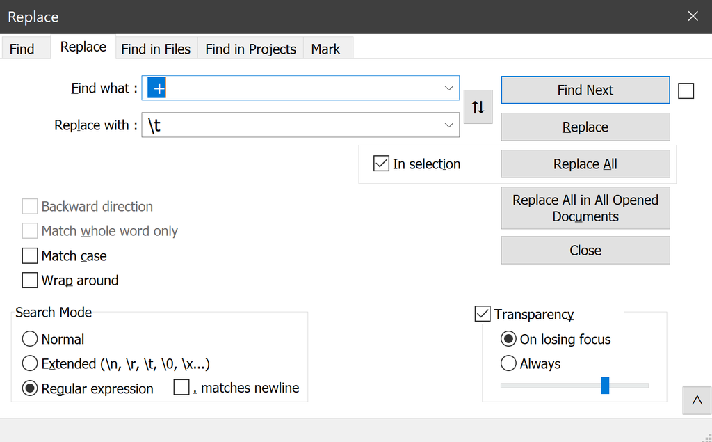

Then, plot the reads in R to identify potential troublemakers.

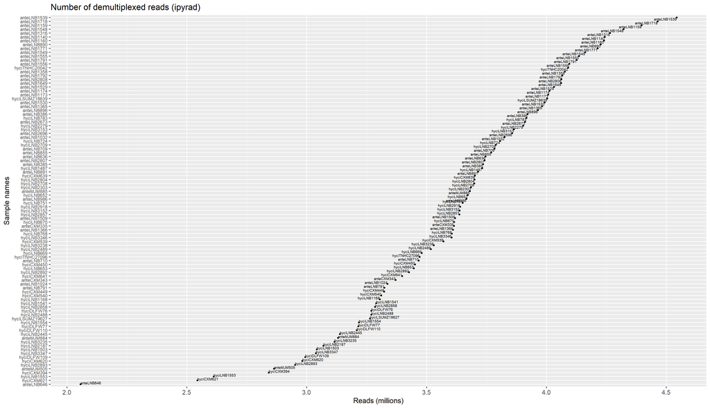

```r
#VISUALIZE RETAINED READS
library(ggplot2)

# Read in the csv file
demux_reads <- read.csv("demux_reads.csv")

# Make the plot, you can change settings as you wish
ggplot(demux_reads, aes(x = total_reads/1e6, y = reorder(sample_name, total_reads), label = sample_name)) + geom_point(size=1) + geom_text(colour = "black", size = 2, vjust="inward",hjust="inward") + labs(title="Number of demultiplexed reads (ipyrad)", x="Reads (millions)", y="Sample names") + theme(axis.text.x = element_text(size = 10), axis.text.y = element_text(size = 7)) #vjust = 1, hjust=1,
```

Additionally, you should upload the `s1_demultiplex_stats.txt` file into our shared ipyrad_demultiplex_stats folder in OneDrive. Make sure to change the name of the file first to reflect the plate number. Such as `Plate01_s1_demultiplex_stats.txt`

# Filtering Reads

## Check read quality

You should check read quality from the MultiQC report for each plate. The “Per-Position Quality Score Ranges**”** and”Per-Position Mean Quality Scores” are the best to look at for our purposes. We generally want the scores to be 20 or above. If ends of the reads have very low quality scores, then we might trim them off. We will most likely not need to do any trimming, but if you come across quality scores that look bad then we can discuss what to do. Parameter 25 controls the trimming process during step 2. See the ipyrad documentation for more info.

## Double check number of samples

You should only start filtering reads for a species once all of the individual samples for that species have been demultiplexed and copied into the species-specific folder such as `Hyla_cinerea/ipyrad_reads`. Using the project spreadsheet, check to see if the species is completed and note the number of samples for that species. Then, use the following command in the species-specific folder:

```bash
ls *_R1_* -1 | wc -l
```

This will give you the number of R1 reads in the folder. Make sure this matches the number listed in the `N_Samples_Sequenced` column of the spreadsheet.

Also use `ls` to view a list of all the samples in the directory. Check that the first and last samples both start with the appropriate species abbreviation. Since the files are sorted alphabetically, if there are any other species present in the directory then they should be at the beginning or end of the list of files.

## Code

In the parameter file below, change:

- the species abbreviation in parameter 0,
- the file paths in parameters 1 and 4

Also, change the species abbreviation for the names of the params and slurm files themselves. You will want to create these files and run them within the `FilteredReadsIpyrad/Species/` folder.

There are several other parameters that matter for running step 2. You do NOT need to change them since they are already changed in the code below; this is more for your information. The other parameters that matter are `phred_Qscore_offset` (default), `datatype` (changed), `restriction_overhang` (changed), `max_low_qual_bases` (default), `filter_adapters` (changed), and `filter_min_trim_len` (default). Look at the ipyrad documentation linked at the top of this page if you want to understand which each does.

`params-hyci_step12.txt`

```bash
------- ipyrad params file (v.0.9.102)------------------------------------------
hyci_step12                           ## [0] [assembly_name]: Assembly name. Used to name output directories for assembly steps
/carc/scratch/projects/lnbarrow2016221/FilteredReadsIpyrad/Hyla_cinerea/ ## [1] [project_dir]: Project dir (made in curdir if not present)
                               ## [2] [raw_fastq_path]: Location of raw non-demultiplexed fastq files
                               ## [3] [barcodes_path]: Location of barcodes file
/carc/scratch/projects/lnbarrow2016221/DemultiplexedReads/Hyla_cinerea/ipyrad_reads/*R1_.fastq.gz                               ## [4] [sorted_fastq_path]: Location of demultiplexed/sorted fastq files
denovo                         ## [5] [assembly_method]: Assembly method (denovo, reference)
                               ## [6] [reference_sequence]: Location of reference sequence file
ddrad                            ## [7] [datatype]: Datatype (see docs): rad, gbs, ddrad, etc.
TGCAGG,                         ## [8] [restriction_overhang]: Restriction overhang (cut1,) or (cut1, cut2)
5                              ## [9] [max_low_qual_bases]: Max low quality base calls (Q<20) in a read
33                             ## [10] [phred_Qscore_offset]: phred Q score offset (33 is default and very standard)
6                              ## [11] [mindepth_statistical]: Min depth for statistical base calling
6                              ## [12] [mindepth_majrule]: Min depth for majority-rule base calling
10000                          ## [13] [maxdepth]: Max cluster depth within samples
0.85                           ## [14] [clust_threshold]: Clustering threshold for de novo assembly
0                              ## [15] [max_barcode_mismatch]: Max number of allowable mismatches in barcodes
2                              ## [16] [filter_adapters]: Filter for adapters/primers (1 or 2=stricter)
35                             ## [17] [filter_min_trim_len]: Min length of reads after adapter trim
2                              ## [18] [max_alleles_consens]: Max alleles per site in consensus sequences
0.05                           ## [19] [max_Ns_consens]: Max N's (uncalled bases) in consensus
0.05                           ## [20] [max_Hs_consens]: Max Hs (heterozygotes) in consensus
4                              ## [21] [min_samples_locus]: Min # samples per locus for output
0.2                            ## [22] [max_SNPs_locus]: Max # SNPs per locus
8                              ## [23] [max_Indels_locus]: Max # of indels per locus
0.5                            ## [24] [max_shared_Hs_locus]: Max # heterozygous sites per locus
0, 0, 0, 0                     ## [25] [trim_reads]: Trim raw read edges (R1>, <R1, R2>, <R2) (see docs)
0, 0, 0, 0                     ## [26] [trim_loci]: Trim locus edges (see docs) (R1>, <R1, R2>, <R2)
p, s, l                        ## [27] [output_formats]: Output formats (see docs)
                               ## [28] [pop_assign_file]: Path to population assignment file
                               ## [29] [reference_as_filter]: Reads mapped to this reference are removed in step 3
```

Make sure to change the email and the name of the parameter file within the slurm script.

`filter_hyci.slurm`

```bash
#!/bin/bash

#SBATCH --ntasks=1
#SBATCH --cpus-per-task=32
#SBATCH --time=48:00:00
#SBATCH --job-name=ipyrad
#SBATCH --output=_ipyrad_out_%j
#SBATCH --error=_ipyrad_error_%j
#SBATCH --partition=general
#SBATCH --account=2016221
#SBATCH --mail-type=ALL
#SBATCH --mail-user=youremail@unm.edu

## activate conda environment
module load miniconda3
source activate ipyrad-env

## call ipyrad on your params file, running step one (demultiplex)
ipyrad -p params-hyci_step12.txt -s 12 -c ${SLURM_CPUS_PER_TASK}
```

Now, run the slurm script using the `sbatch` command.

Once the job is finished running, you need to give permissions to everyone so they can move, edit, and create files/folders. Use the following command to give permission for all files and folders in the `/carc/scratch/projects/lnbarrow2016221`. This may take a few minutes since you are going through every file in the project. You can also use a more specific directory such as `/carc/scratch/projects/lnbarrow2016221/FilteredReadsIpyrad/Hyla_cinerea` (if you use the more specific path, make sure to change the species name).

```bash
chmod -R g+w /carc/scratch/projects/lnbarrow2016221
```

Additionally, you should download the `s2_rawedit_stats.txt` file and then upload it into our shared ipyrad_s2_filtered_reads folder in OneDrive. In the code below, change the full species name and species abbreviation in the first file path. In the second file path, change the species abbreviation as well. This renames our download from `s2_rawedit_stats.txt` to `s2_rawedit_stats_hyci.txt` when we download it. This does not change the name in CARC.

```bash
rsync yourusername@hopper.alliance.unm.edu:/carc/scratch/projects/lnbarrow2016221/FilteredReadsIpyrad/Hyla_cinerea/hyci_step12_edits/s2_rawedit_stats.txt ./s2_rawedit_stats_hyci.txt
```

## Evaluate Filtered Reads

Load the `s2_rawedit_stats.txt` file into R to make a figure showing the amount of raw reads and the amount of reads that past the filtering step for each sample.

```r
library(ggplot2)
library(reshape2)

csv_reads <- read.csv("s2_rawedit_stats_hyci.txt", sep="", row.names=NULL)
colnames(csv_reads)[1] <- 'sample_name'
reads <- csv_reads[c(1,2,7)]
reads2 <- melt(reads, id.vars="sample_name")


ggplot(reads2, aes(x = value/1e6, y = reorder(sample_name,value), col = variable)) + geom_point(size=1) + labs(title="Number of filtered reads (ipyrad)", x="Reads (millions)", y="Sample names") + theme(axis.text.x = element_text(size = 10), axis.text.y = element_text(size = 7))
```

Example:

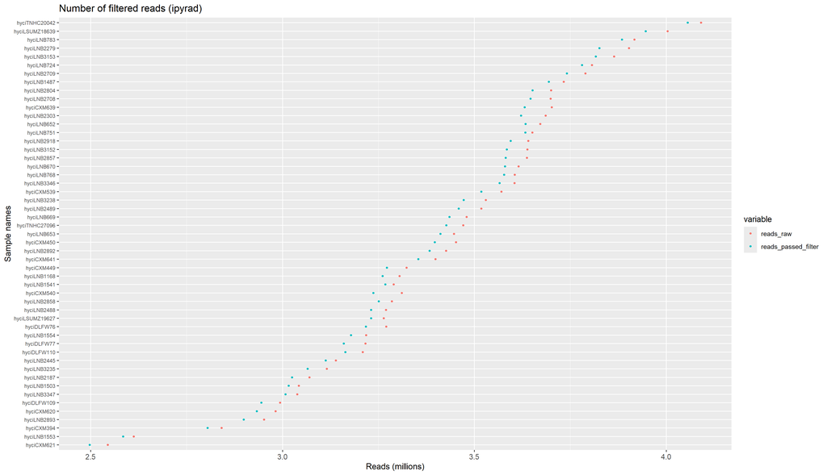

# clustOpt (steps 3-7)

Clustering optimization tries to find the best parameter for [14] [clust_threshold]. This determines how similar sequences need to be to be merged into the same homologous locus, both within and between individuals. If the parameter is too low, it can overmerge paralogs. If the parameter is too high, it can undermerge and homologous loci are instead treated as separate loci. This can affect measures of genetic variation/diversity and potentially other analyses. Generally speaking, assemblies that contain multiple species/divergent lineages will have lower clustering thresholds. More details can be found in the paper: “An empirical pipeline for choosing the optimal clustering threshold in RADseq studies” https://onlinelibrary.wiley.com/doi/10.1111/1755-0998.13029

We will be testing for each clustering threshold between 0.85-0.97 (0.85, 0.86, 0.87, 0.88, 0.89, 0.90, 0.91, 0.92, 0.93, 0.94, 0.95, 0.96, 0.97). We will then run all 7 steps of ipyrad for these different clustering thresholds. You will need to create both a slurm script and a parameter file for each threshold.

## Make a species directory

First, make a species directory within `/carc/scratch/projects/lnbarrow2016221/ipyradAssemblies/` such as `Hyla_cinerea`, using the following command:

```bash
mkdir Hyla_cinerea
```

Next go into the new folder using the `cd Hyla_cinerea` command. Then, make a clustOpt folder.

```bash
mkdir clustOpt
```

### “Restarting” a clustOpt directory

If clustOpt was already run and you are rerunning it, you will need to move the current contents of the clustOpt directory into the species subdirectory within the Z_OLD directory.

First, make a species directory within Z_OLD if it doesn’t exist yet.

```bash
mkdir Z_OLD/Hyla_cinerea
```

Then, move contents from the clustOpt directory into the Z_OLD directory.

```bash
mv Hyla_cinerea/clustOpt/* Z_OLD/Hyla_cinerea
```

Now you can use `cd Hyla_cinerea` to go into the species directory and start anew.

## Parameter file

Use `cd clustOpt` to go into the new clustOpt folder. Run the following command. Make sure to replace the hyci with your species abbreviation:

```bash
nano params-hyci_clustOpt85.txt
```

This will open an empty file that you should copy and paste the below parameter file text into.

Within the parameter file, you need to change:

- Parameter 0 [assembly_name]: change the species abbreviation
- Parameter 1 [project_directory]: change the species folder name
- Parameter 4 [sorted_fastq_path]: change the species folder name and the species abbreviation

Save the code using `CTRL + O` and then press `ENTER`. Use `CTRL + X` to exit.

```bash
------- ipyrad params file (v.0.9.102)------------------------------------------
hyci_clustOpt85                         ## [0] [assembly_name]: Assembly name. Used to name output directories for assembly steps
/carc/scratch/projects/lnbarrow2016221/ipyradAssemblies/Hyla_cinerea/clustOpt/ ## [1] [project_dir]: Project dir (made in curdir if not present)
                               ## [2] [raw_fastq_path]: Location of raw non-demultiplexed fastq files
                               ## [3] [barcodes_path]: Location of barcodes file
/carc/scratch/projects/lnbarrow2016221/FilteredReadsIpyrad/Hyla_cinerea/hyci_step12_edits/*trimmed_R1_.fastq.gz                               ## [4] [sorted_fastq_path]: Location of demultiplexed/sorted fastq files
denovo                         ## [5] [assembly_method]: Assembly method (denovo, reference)
                               ## [6] [reference_sequence]: Location of reference sequence file
ddrad                            ## [7] [datatype]: Datatype (see docs): rad, gbs, ddrad, etc.
TGCAGG,                         ## [8] [restriction_overhang]: Restriction overhang (cut1,) or (cut1, cut2)
5                              ## [9] [max_low_qual_bases]: Max low quality base calls (Q<20) in a read
33                             ## [10] [phred_Qscore_offset]: phred Q score offset (33 is default and very standard)
6                              ## [11] [mindepth_statistical]: Min depth for statistical base calling
6                              ## [12] [mindepth_majrule]: Min depth for majority-rule base calling
10000                          ## [13] [maxdepth]: Max cluster depth within samples
0.85                           ## [14] [clust_threshold]: Clustering threshold for de novo assembly
0                              ## [15] [max_barcode_mismatch]: Max number of allowable mismatches in barcodes
2                              ## [16] [filter_adapters]: Filter for adapters/primers (1 or 2=stricter)
35                             ## [17] [filter_min_trim_len]: Min length of reads after adapter trim
2                              ## [18] [max_alleles_consens]: Max alleles per site in consensus sequences
0.05                           ## [19] [max_Ns_consens]: Max N's (uncalled bases) in consensus
0.05                           ## [20] [max_Hs_consens]: Max Hs (heterozygotes) in consensus
4                              ## [21] [min_samples_locus]: Min # samples per locus for output
0.2                            ## [22] [max_SNPs_locus]: Max # SNPs per locus
8                              ## [23] [max_Indels_locus]: Max # of indels per locus
0.5                            ## [24] [max_shared_Hs_locus]: Max # heterozygous sites per locus
0, 0, 0, 0                     ## [25] [trim_reads]: Trim raw read edges (R1>, <R1, R2>, <R2) (see docs)
0, 0, 0, 0                     ## [26] [trim_loci]: Trim locus edges (see docs) (R1>, <R1, R2>, <R2)
*                        ## [27] [output_formats]: Output formats (see docs)
                               ## [28] [pop_assign_file]: Path to population assignment file
                               ## [29] [reference_as_filter]: Reads mapped to this reference are removed in step 3
```

## slurm script

Use `nano` again to open an empty text file. Make sure to change the species abbreviation:

```bash
nano hyci_clustOpt85.slurm
```

Copy and paste the below code into the file.

You will need to change:

- the email
- the species abbreviation in the params text file name

Save the code using `CTRL + O` and then press `ENTER`. Use `CTRL + X` to exit.

```bash
#!/bin/bash

#SBATCH --ntasks=1
#SBATCH --cpus-per-task=32
#SBATCH --time=48:00:00
#SBATCH --job-name=clust085
#SBATCH --output=_clustOpt85_out_%j
#SBATCH --error=_clustOpt85_error_%j
#SBATCH --partition=general
#SBATCH --account=2016221
#SBATCH --mail-type=ALL
#SBATCH --mail-user=youremail@unm.edu

## activate conda environment
module load miniconda3
source activate ipyrad-env

## call ipyrad on your params file, running step one (demultiplex)
ipyrad -p params-hyci_clustOpt85.txt -s 1234567 -c ${SLURM_CPUS_PER_TASK}
```

## for Loop

We need to create parameter files and slurm scripts for the remaining clustering thresholds. We can use a for loop to automatically duplicate the files and replace the clustering threshold parameter. This for loop goes through numbers 86-97, and for each number it copies the slurm file and parameter file you just made, renames the new file with the current number, and replaces all instances of 85 within the files with the new number. The below code should all be on one line and run directly in the console. Make sure to change the species abbreviations to your species (there are 6 instances that need to be changed).

```bash
for num in {86..97}; do cp params-hyci_clustOpt85.txt params-hyci_clustOpt$num.txt; sed -i "s/85/$num/g" params-hyci_clustOpt$num.txt; cp hyci_clustOpt85.slurm hyci_clustOpt$num.slurm; sed -i "s/85/$num/g" hyci_clustOpt$num.slurm; done
```

You should now have a total of 13 slurm files and 13 parameter files.

Double check that the numbers within the files were successfully changed in at least one of each of the slurm and parameter files. Use the `cat` or `less` command followed by the file name to view the contents. For the slurm script, this should change the number in the parameter file name, and in the commands for job name, output, and error file names. For the parameter file, this should change parameters [0] (assembly_name) and 14 (clust_threshold).

## Double check number of samples

Before running clustOpt, double check that the number of samples in the FilteredReads directory is the correct number of samples. DOWNLOAD (do not open or make changes) the ALL_Samples_Sequenced_20250821.xlsx spreadsheet found in the project folder. Filter the `Species_Binomial` column to your species and filter the `mapPaper_YN` column to “Yes”. The number of samples should match the number indicated in the `N_Samples_Updated` of the project spreadsheet. You can use the following command in the species-specific folder. Make sure to change the species name and species abbreviation in the file path.

```bash
ls /carc/scratch/projects/lnbarrow2016221/FilteredReadsIpyrad/Hyla_cinerea/hyci_step12_edits/*_R1_* -1 | wc -l
```

This will give you the number of R1 reads in the folder. Make sure this matches the number listed in the `N_Samples_Updated` column of the spreadsheet.

Also use `ls` to view a list of all the samples in the directory.

`ls /carc/scratch/projects/lnbarrow2016221/FilteredReadsIpyrad/Hyla_cinerea/hyci_step12_edits/`

Note, don’t assume the species prefixes are “wrong” - for example, the ‘ancowo’ and ‘anfo’ samples were misidentified originally, and they have been correctly moved to the Anaxyrus woodhousii (‘anwo’) folder.

## Run all clustOpt assemblies

We now want to run all clustOpt assemblies. We can do this on Hopper or Easley, and we can run multiple assemblies at once. We can also use a `for` loop for this. Again, make sure to change the species abbreviation. We will run clustOpt thresholds for 85-97.

```bash
for num in {85..97}; do sbatch hyci_clustOpt$num.slurm; done
```

Use the `squeue -u yourusername` command to check to see which jobs are running. Once a job has been running for a few minutes, check the file called `_clustOpt_##out_####` for the associated job. Make sure that the “loading reads” step at the very beginning moves past 0%. If it gets stuck at 0%, you will want to rerun that individual job. If this happens, use `scancel` followed by a space and the jobID number to stop it. Then use `sbatch` followed by the name of that specific clustOpt slurm file to rerun it.

Once each of your clustOpt jobs finishes, check the very end of your `_clustOpt_##out_####` file using the `cat` command to make sure step 7 completed. It should say something like:

> [####################] 100% 0:06:14 | writing vcf output

> Parallel connection closed.

If the file does not end with the vcf output finishing at 100%, there are two main reasons. Please see below under the Potential Problems section.

## Potential Problems

### Timeouts

Sometimes a run will TIME OUT and hit the 48 hour time limit for jobs. You will get an email that says something like:

> Slurm Job_id=6130 Name=clustOpt98 Failed, Run time 2-00:00:07, TIMEOUT, ExitCode 0

This will likely happen with the higher clustering thresholds (potentially 96-97). Additionally, if you have a lot of individual samples then it’s possible that the thresholds 85-94 may time out. If this happens, you need to check to see which steps in ipyrad were completed. Download the out file like below:

```bash
rsync yourusername@hopper.alliance.unm.edu:/carc/scratch/projects/lnbarro
w2016221/ipyradAssemblies/Hyla_cinerea/clustOpt/_clustOpt98_out_6130 .
```

Then, open the downloaded file in a text editor (Notepad++ or similar) and search/find the word “step”. If step 4 or later has been started, then the run can be continued as a new job.

If the run stopped during step 7, we will rerun step 7. If it stopped during step 5, we will run steps 5, 6, and 7. Etc.

Once you have identified what step the run stopped at, make a copy of the slurm script associated with the original run. You can use a copy command to make a copy of the slurm script with a new name, like below.

```bash
cp hyci_clustOpt85.slurm hyci_clustOpt85_step7.slurm
```

Then, open the new slurm script using `nano`. In this example, we are starting the run from step 7, so we change the `-s` parameter to `7` (rather than `1234567`). If you were to start at step 5, you would want to change it to `567`. Additionally, add `–-force` at the end of the line of commands. This allows ipyrad to overwrite the previous step 7. An example of the old and updated line from the slurm scripts are below.

Old script:

```bash
ipyrad -p params-rasp_clustOpt96.txt -s 1234567 -c ${SLURM_CPUS_PER_TASK}
```

New script:

```bash
ipyrad -p params-rasp_clustOpt96.txt -s 7 -c ${SLURM_CPUS_PER_TASK} --force
```

Save and exit the slurm file, and then run it using `sbatch`.

### Step 7 errors

Another potential issue is some individual samples will not make it to step 6, so when step 7 tries to run you will get the following error:

> Step 7: Filtering and formatting output files

> Encountered an Error.

> Message:

> There are samples in this assembly that were not present in step 6. This is

> likely due to failed samples retained in the assembly from prior to step 5, or

> branching/merging. Either branch and remove these samples, or run them through

> step 6. The following samples are not in the step6 database:

> {‘B_FHSM11034.trimmed’, ‘B_FHSM9013.trimmed’}

> Simplest solution is to branch and remove these from the assembly.

> Parallel connection closed.

You will need to branch the original run into a second run. First load your ipyrad environment:

```bash
module load miniconda3
source activate ipyrad-env
```

Then, run the following command to branch a new run that excludes the missing samples. The `-p` parameter should be the parameter file of the original run that you are branching off of. The `-b` parameter should be the new assembly name. Everything after the `-` should be a list of the samples to exclude. After you run the below code (make sure to modify the names and samples), it will create a new parameter file named like `params-hyci_clustOpt85_step7.txt`.

```bash
ipyrad -p params-hyci_clustOpt85.txt -b hyci_clustOpt85_step7 - FLMNH162452.trimmed B_MSB74657-B.trimmed
```

Here is a copy of code that includes ALL clustOpt85-97. Make sure to change the species abbreviation and the samples being removed. Each line below should be run SEPARATELY.

```bash
ipyrad -p params-hyci_clustOpt85.txt -b hyci_clustOpt85_step7 - FLMNH162452.trimmed B_MSB74657-B.trimmed
ipyrad -p params-hyci_clustOpt86.txt -b hyci_clustOpt86_step7 - FLMNH162452.trimmed B_MSB74657-B.trimmed
ipyrad -p params-hyci_clustOpt87.txt -b hyci_clustOpt87_step7 - FLMNH162452.trimmed B_MSB74657-B.trimmed
ipyrad -p params-hyci_clustOpt88.txt -b hyci_clustOpt88_step7 - FLMNH162452.trimmed B_MSB74657-B.trimmed
ipyrad -p params-hyci_clustOpt89.txt -b hyci_clustOpt89_step7 - FLMNH162452.trimmed B_MSB74657-B.trimmed
ipyrad -p params-hyci_clustOpt90.txt -b hyci_clustOpt90_step7 - FLMNH162452.trimmed B_MSB74657-B.trimmed
ipyrad -p params-hyci_clustOpt91.txt -b hyci_clustOpt91_step7 - FLMNH162452.trimmed B_MSB74657-B.trimmed
ipyrad -p params-hyci_clustOpt92.txt -b hyci_clustOpt92_step7 - FLMNH162452.trimmed B_MSB74657-B.trimmed
ipyrad -p params-hyci_clustOpt93.txt -b hyci_clustOpt93_step7 - FLMNH162452.trimmed B_MSB74657-B.trimmed
ipyrad -p params-hyci_clustOpt94.txt -b hyci_clustOpt94_step7 - FLMNH162452.trimmed B_MSB74657-B.trimmed
ipyrad -p params-hyci_clustOpt95.txt -b hyci_clustOpt95_step7 - FLMNH162452.trimmed B_MSB74657-B.trimmed
ipyrad -p params-hyci_clustOpt96.txt -b hyci_clustOpt96_step7 - FLMNH162452.trimmed B_MSB74657-B.trimmed
ipyrad -p params-hyci_clustOpt97.txt -b hyci_clustOpt97_step7 - FLMNH162452.trimmed B_MSB74657-B.trimmed
```

It should output text like so:

> ipyrad -p params-psni_clustOpt85.txt -b psni_clustOpt85_step7 - psniNCSM87415.trimmed

> loading Assembly: psni_clustOpt85

> from saved path: /carc/scratch/projects/lnbarrow2016221/ipyradAssemblies/Pseudacris_nigrita/clustOpt/psni_clustOpt85.json

> dropping 1 samples

> creating a new branch called ‘psni_clustOpt85_step7’ with 27 Samples

> writing new params file to params-psni_clustOpt85_step7.txt

Now that you have branched your assembly, make a copy of the slurm script associated with the original run. You can use a copy command to make a copy of the slurm script with a new name, like below.

```bash
cp hyci_clustOpt85.slurm hyci_clustOpt85_step7.slurm
```

Then, open the new slurm script using `nano`. Change the parameter file to the new parameter file we created from branching. Also change the `-s` parameter to `7` (rather than `1234567`). Save and exit the slurm file, and then run it using `sbatch`.

### Check which nodes are available

To check available nodes on the “general” partition, use the following:

```bash
sinfo -p general
```

This works for both Easley and Hopper since they both have a partition called “general”. You can change it to “toadpole” to check the status of our Hopper node as well.

A state of “idle” means the node is not being used. “alloc” means all the CPUs are being used for that node. “mixed” means some CPUs on the node are being used, but some are still available.

For more details on the number of idle nodes, use the following:

```bash
sinfo -p general  -o "%P %n %t %C"
```

The last column shows the number of CPUs in the format of allocated/idle/other/total. For example, 24/8/0/32 means there are 24 CPUs in use, 8 idle CPUs, 0 CPUs with other statuses, and 32 CPUs in total for that node.

You can specify a specific node in your slurm scripts by replacing “nodename” with the name generated from `sinfo`. An example of a node name on Hopper is “hopper001”.

```bash
#SBATCH --nodelist=nodename
```

## Permissions and File Export

Make sure you give everyone on the project permission to create, edit, etc. with the new files and folders you generated. Make sure to change the species folder name:

```bash
chmod -R g+w /carc/scratch/projects/lnbarrow2016221/ipyradAssemblies/Hyla_cinerea/clustOpt
```

For this next part of file export, **ON YOUR LOCAL COMPUTER, NOT IN CARC:**

For the clustOpt analyses, you will need to download three files for each clustering threshold that will be used to evaluate the different clustering thresholds. These files are:

- hyci_clustOpt##_stats.txt
- hyci_clustOpt##.vcf
- s5_consens_stats.txt

To download, open up a command line/ubuntu/etc. that is not logged into CARC. Set your working directory to where you want the files downloaded. (`cd` and then space and the folder path). Then, run this code as a single line. You will need to find and replace `Hyla_cinerea` with your species name, `hyci` with you species abbreviation, and `youruser` with whatever is your CARC username.

```bash
rsync youruser@hopper.alliance.unm.edu:/carc/scratch/projects/lnbarrow2016221/ipyradAssemblies/Hyla_cinerea/clustOpt/hyci_clustOpt85_outfiles/hyci_clustOpt85_stats.txt youruser@hopper.alliance.unm.edu:/carc/scratch/projects/lnbarrow2016221/ipyradAssemblies/Hyla_cinerea/clustOpt/hyci_clustOpt86_outfiles/hyci_clustOpt86_stats.txt youruser@hopper.alliance.unm.edu:/carc/scratch/projects/lnbarrow2016221/ipyradAssemblies/Hyla_cinerea/clustOpt/hyci_clustOpt87_outfiles/hyci_clustOpt87_stats.txt youruser@hopper.alliance.unm.edu:/carc/scratch/projects/lnbarrow2016221/ipyradAssemblies/Hyla_cinerea/clustOpt/hyci_clustOpt88_outfiles/hyci_clustOpt88_stats.txt youruser@hopper.alliance.unm.edu:/carc/scratch/projects/lnbarrow2016221/ipyradAssemblies/Hyla_cinerea/clustOpt/hyci_clustOpt89_outfiles/hyci_clustOpt89_stats.txt youruser@hopper.alliance.unm.edu:/carc/scratch/projects/lnbarrow2016221/ipyradAssemblies/Hyla_cinerea/clustOpt/hyci_clustOpt90_outfiles/hyci_clustOpt90_stats.txt youruser@hopper.alliance.unm.edu:/carc/scratch/projects/lnbarrow2016221/ipyradAssemblies/Hyla_cinerea/clustOpt/hyci_clustOpt91_outfiles/hyci_clustOpt91_stats.txt youruser@hopper.alliance.unm.edu:/carc/scratch/projects/lnbarrow2016221/ipyradAssemblies/Hyla_cinerea/clustOpt/hyci_clustOpt92_outfiles/hyci_clustOpt92_stats.txt youruser@hopper.alliance.unm.edu:/carc/scratch/projects/lnbarrow2016221/ipyradAssemblies/Hyla_cinerea/clustOpt/hyci_clustOpt93_outfiles/hyci_clustOpt93_stats.txt youruser@hopper.alliance.unm.edu:/carc/scratch/projects/lnbarrow2016221/ipyradAssemblies/Hyla_cinerea/clustOpt/hyci_clustOpt94_outfiles/hyci_clustOpt94_stats.txt youruser@hopper.alliance.unm.edu:/carc/scratch/projects/lnbarrow2016221/ipyradAssemblies/Hyla_cinerea/clustOpt/hyci_clustOpt95_outfiles/hyci_clustOpt95_stats.txt youruser@hopper.alliance.unm.edu:/carc/scratch/projects/lnbarrow2016221/ipyradAssemblies/Hyla_cinerea/clustOpt/hyci_clustOpt96_outfiles/hyci_clustOpt96_stats.txt youruser@hopper.alliance.unm.edu:/carc/scratch/projects/lnbarrow2016221/ipyradAssemblies/Hyla_cinerea/clustOpt/hyci_clustOpt97_outfiles/hyci_clustOpt97_stats.txt youruser@hopper.alliance.unm.edu:/carc/scratch/projects/lnbarrow2016221/ipyradAssemblies/Hyla_cinerea/clustOpt/hyci_clustOpt85_outfiles/hyci_clustOpt85.vcf youruser@hopper.alliance.unm.edu:/carc/scratch/projects/lnbarrow2016221/ipyradAssemblies/Hyla_cinerea/clustOpt/hyci_clustOpt86_outfiles/hyci_clustOpt86.vcf youruser@hopper.alliance.unm.edu:/carc/scratch/projects/lnbarrow2016221/ipyradAssemblies/Hyla_cinerea/clustOpt/hyci_clustOpt87_outfiles/hyci_clustOpt87.vcf youruser@hopper.alliance.unm.edu:/carc/scratch/projects/lnbarrow2016221/ipyradAssemblies/Hyla_cinerea/clustOpt/hyci_clustOpt88_outfiles/hyci_clustOpt88.vcf youruser@hopper.alliance.unm.edu:/carc/scratch/projects/lnbarrow2016221/ipyradAssemblies/Hyla_cinerea/clustOpt/hyci_clustOpt89_outfiles/hyci_clustOpt89.vcf youruser@hopper.alliance.unm.edu:/carc/scratch/projects/lnbarrow2016221/ipyradAssemblies/Hyla_cinerea/clustOpt/hyci_clustOpt90_outfiles/hyci_clustOpt90.vcf youruser@hopper.alliance.unm.edu:/carc/scratch/projects/lnbarrow2016221/ipyradAssemblies/Hyla_cinerea/clustOpt/hyci_clustOpt91_outfiles/hyci_clustOpt91.vcf youruser@hopper.alliance.unm.edu:/carc/scratch/projects/lnbarrow2016221/ipyradAssemblies/Hyla_cinerea/clustOpt/hyci_clustOpt92_outfiles/hyci_clustOpt92.vcf youruser@hopper.alliance.unm.edu:/carc/scratch/projects/lnbarrow2016221/ipyradAssemblies/Hyla_cinerea/clustOpt/hyci_clustOpt93_outfiles/hyci_clustOpt93.vcf youruser@hopper.alliance.unm.edu:/carc/scratch/projects/lnbarrow2016221/ipyradAssemblies/Hyla_cinerea/clustOpt/hyci_clustOpt94_outfiles/hyci_clustOpt94.vcf youruser@hopper.alliance.unm.edu:/carc/scratch/projects/lnbarrow2016221/ipyradAssemblies/Hyla_cinerea/clustOpt/hyci_clustOpt95_outfiles/hyci_clustOpt95.vcf youruser@hopper.alliance.unm.edu:/carc/scratch/projects/lnbarrow2016221/ipyradAssemblies/Hyla_cinerea/clustOpt/hyci_clustOpt96_outfiles/hyci_clustOpt96.vcf youruser@hopper.alliance.unm.edu:/carc/scratch/projects/lnbarrow2016221/ipyradAssemblies/Hyla_cinerea/clustOpt/hyci_clustOpt97_outfiles/hyci_clustOpt97.vcf .
```

You should now have 26 files downloaded. You need to download 13 more files. Because they have the same name, we will need to downloaded each one-by-one and rename the downloaded file. In the section below, each line should be run separately (each line begins with `rsync`). Replace the username, species name, and species abbreviations.

```bash
rsync youruser@hopper.alliance.unm.edu:/carc/scratch/projects/lnbarrow2016221/ipyradAssemblies/Hyla_cinerea/clustOpt/hyci_clustOpt85_consens/s5_consens_stats.txt ./hyci_clustOpt85_s5_consensus.txt
rsync youruser@hopper.alliance.unm.edu:/carc/scratch/projects/lnbarrow2016221/ipyradAssemblies/Hyla_cinerea/clustOpt/hyci_clustOpt86_consens/s5_consens_stats.txt ./hyci_clustOpt86_s5_consensus.txt
rsync youruser@hopper.alliance.unm.edu:/carc/scratch/projects/lnbarrow2016221/ipyradAssemblies/Hyla_cinerea/clustOpt/hyci_clustOpt87_consens/s5_consens_stats.txt ./hyci_clustOpt87_s5_consensus.txt
rsync youruser@hopper.alliance.unm.edu:/carc/scratch/projects/lnbarrow2016221/ipyradAssemblies/Hyla_cinerea/clustOpt/hyci_clustOpt88_consens/s5_consens_stats.txt ./hyci_clustOpt88_s5_consensus.txt
rsync youruser@hopper.alliance.unm.edu:/carc/scratch/projects/lnbarrow2016221/ipyradAssemblies/Hyla_cinerea/clustOpt/hyci_clustOpt89_consens/s5_consens_stats.txt ./hyci_clustOpt89_s5_consensus.txt
rsync youruser@hopper.alliance.unm.edu:/carc/scratch/projects/lnbarrow2016221/ipyradAssemblies/Hyla_cinerea/clustOpt/hyci_clustOpt90_consens/s5_consens_stats.txt ./hyci_clustOpt90_s5_consensus.txt
rsync youruser@hopper.alliance.unm.edu:/carc/scratch/projects/lnbarrow2016221/ipyradAssemblies/Hyla_cinerea/clustOpt/hyci_clustOpt91_consens/s5_consens_stats.txt ./hyci_clustOpt91_s5_consensus.txt
rsync youruser@hopper.alliance.unm.edu:/carc/scratch/projects/lnbarrow2016221/ipyradAssemblies/Hyla_cinerea/clustOpt/hyci_clustOpt92_consens/s5_consens_stats.txt ./hyci_clustOpt92_s5_consensus.txt
rsync youruser@hopper.alliance.unm.edu:/carc/scratch/projects/lnbarrow2016221/ipyradAssemblies/Hyla_cinerea/clustOpt/hyci_clustOpt93_consens/s5_consens_stats.txt ./hyci_clustOpt93_s5_consensus.txt
rsync youruser@hopper.alliance.unm.edu:/carc/scratch/projects/lnbarrow2016221/ipyradAssemblies/Hyla_cinerea/clustOpt/hyci_clustOpt94_consens/s5_consens_stats.txt ./hyci_clustOpt94_s5_consensus.txt
rsync youruser@hopper.alliance.unm.edu:/carc/scratch/projects/lnbarrow2016221/ipyradAssemblies/Hyla_cinerea/clustOpt/hyci_clustOpt95_consens/s5_consens_stats.txt ./hyci_clustOpt95_s5_consensus.txt
rsync youruser@hopper.alliance.unm.edu:/carc/scratch/projects/lnbarrow2016221/ipyradAssemblies/Hyla_cinerea/clustOpt/hyci_clustOpt96_consens/s5_consens_stats.txt ./hyci_clustOpt96_s5_consensus.txt
rsync youruser@hopper.alliance.unm.edu:/carc/scratch/projects/lnbarrow2016221/ipyradAssemblies/Hyla_cinerea/clustOpt/hyci_clustOpt97_consens/s5_consens_stats.txt ./hyci_clustOpt97_s5_consensus.txt
```

## clustOpt Analyses

We will be using the downloaded files to look at 5 of 7 metrics as described in the paper “An empirical pipeline for choosing the optimal clustering threshold in RADseq studies” by McCartney-Melstad et al. More details can be seen here: https://doi.org/10.1111/1755-0998.13029 We will be using code and modified code from their associated GitHub repository: https://github.com/atcg/clustOpt. Some of the modifications were made with the help of ChatGPT.

For each of the metrics below, I will show how the paper says to interpret the results, the figure from the paper, the interpretation of that figure, and then an example from *Hyla cinerea*. Note that some species may have messy data and will not be as straightforward to interpret as what’s in the paper. For more info on the biological explanations and assumptions behind these metrics, see the paper.

Additionally, I have created an R script that has the code for all the metrics in one convenient location. The only thing you should need to change in the code are the lines with the “prefix” variable. You will change this from “hyci” to your species abbreviation. Make sure to save this code and upload it at the end with your generated plots and csv files. You should name your R script `hyci_clustOpt.R` (replace the species abbreviation in the file name).

### Correlation of Pairwise Divergence with Pairwise Missingness

This metric takes the longest to run (anywhere from 40 minutes to 4 hours), so this should be done first. It is done mostly on CARC, with some R locally. All other metrics will be done solely using R.

**LOG BACK INTO CARC:**

First, log into CARC and cd into your species directory. Change the species name.

```bash
cd /carc/scratch/projects/lnbarrow2016221/ipyradAssemblies/Hyla_cinerea/clustOpt
```

Make a new directory called `hyci_missingness` (change the species abbreviation):

```bash
mkdir hyci_missingness
```

Then go into the new directory using the `cd` command. Change the species abbreviation.

```bash
cd hyci_missingness
```

Within the new directory, you will want to copy over a folder and a file that will be used for each species. In the following two commands below, do NOT change the species name.

```bash
cp ../../../MISSINGNESS/vcfMissingness_edited.pl .
```

```bash
cp -r ../../../MISSINGNESS/resources .
```

Now, using `nano`, we need to make a txt file that lists all 13 of your vcf files. Make sure to change the species abbreviation:

```bash
nano hyci_vcfListFile.txt
```

Paste in the following code. Each vcf file should be on a new line. In the example below, change the species abbreviations.

```
hyci_clustOpt85.vcf
hyci_clustOpt86.vcf
hyci_clustOpt87.vcf
hyci_clustOpt88.vcf
hyci_clustOpt89.vcf
hyci_clustOpt90.vcf
hyci_clustOpt91.vcf
hyci_clustOpt92.vcf
hyci_clustOpt93.vcf
hyci_clustOpt94.vcf
hyci_clustOpt95.vcf
hyci_clustOpt96.vcf
hyci_clustOpt97.vcf
```

Save the file using `CTRL + O` and then press `ENTER`. Use `CTRL + X` to exit.

Next, we need to copy over the .vcf files for each of our clustering thresholds into our missingness folder. Make sure to change the species abbreviations.

```bash
cp ../../clustOpt/hyci_clustOpt85_outfiles/hyci_clustOpt85.vcf .
cp ../../clustOpt/hyci_clustOpt86_outfiles/hyci_clustOpt86.vcf .
cp ../../clustOpt/hyci_clustOpt87_outfiles/hyci_clustOpt87.vcf .
cp ../../clustOpt/hyci_clustOpt88_outfiles/hyci_clustOpt88.vcf .
cp ../../clustOpt/hyci_clustOpt89_outfiles/hyci_clustOpt89.vcf .
cp ../../clustOpt/hyci_clustOpt90_outfiles/hyci_clustOpt90.vcf .
cp ../../clustOpt/hyci_clustOpt91_outfiles/hyci_clustOpt91.vcf .
cp ../../clustOpt/hyci_clustOpt92_outfiles/hyci_clustOpt92.vcf .
cp ../../clustOpt/hyci_clustOpt93_outfiles/hyci_clustOpt93.vcf .
cp ../../clustOpt/hyci_clustOpt94_outfiles/hyci_clustOpt94.vcf .
cp ../../clustOpt/hyci_clustOpt95_outfiles/hyci_clustOpt95.vcf .
cp ../../clustOpt/hyci_clustOpt96_outfiles/hyci_clustOpt96.vcf .
cp ../../clustOpt/hyci_clustOpt97_outfiles/hyci_clustOpt97.vcf .
```

Now that we have all the files we need, we must create a new environment for vcftools. You do NOT need to do this if you’ve already created this environment.

```bash
module load miniconda3
conda create -n vcftools-env -c bioconda vcftools
```

Run vcftools for each clustering threshold with the code below. Open the nano text editor. Make sure to change the species abbreviation.

```bash
nano hyci_vcftools.slurm
```

Paste in the following code. Make sure to change species abbreviation, your email, and your username in the path. Save the code using `CTRL + O` and then press `ENTER`. Use `CTRL + X` to exit.

```bash
#!/bin/bash

#SBATCH --ntasks=1
#SBATCH --cpus-per-task=1
#SBATCH --time=00:30:00
#SBATCH --job-name=vcftools
#SBATCH --output=_vcftools_out_%j
#SBATCH --error=_vcftools_error_%j
#SBATCH --partition=general
#SBATCH --account=2016221
#SBATCH --mail-type=ALL
#SBATCH --mail-user=youremail@unm.edu

# Load the environment
module load miniconda3
source activate vcftools-env

# Set a path to your vcftools library to avoid errors
export LD_LIBRARY_PATH=$LD_LIBRARY_PATH:/carc/scratch/users/youruser/.conda/envs/vcftools-env/lib

# Set your species abbreviation
PREFIX="hyci"

# Run vcftools in a loop for files 85 through 97
for i in {85..97}; do
    vcftools --vcf "${PREFIX}_clustOpt${i}.vcf" --012 --out "${PREFIX}_clustOpt${i}_missHM012"
done
```

Now you can submit your job (change the species abbreviation).

```bash
sbatch hyci_vcftools.slurm
```

It should output four files for each threshold and end in `.012`, `.012.ind`, `.012.pos`, and `.log`. Once vcftools is done for all thresholds, we are going to run a perl script as a bash job. Open the nano text editor. Make sure to change the species abbreviation.

```bash
nano hyci_missingness.slurm
```

Paste in the following code. Make sure to change species abbreviation for “PREFIX” and your email. Save the code using `CTRL + O` and then press `ENTER`. Use `CTRL + X` to exit. **NOTE:** If you have many samples, there may not be enough memory to run this step. If this is the case, add the line `#SBATCH --mem=10G`.

```bash
#!/bin/bash

#SBATCH --ntasks=1
#SBATCH --cpus-per-task=1
#SBATCH --time=1:00:00
#SBATCH --job-name=missingness
#SBATCH --output=_miss_out_%A_%a
#SBATCH --error=_miss_error_%A_%a
#SBATCH --partition=general
#SBATCH --account=2016221
#SBATCH --mail-type=ALL
#SBATCH --mail-user=youremail@unm.edu
#SBATCH --array=0-12%8   # 13 jobs total, run max 8 at a time

# Load the environment
module load perl

# Set species prefix
PREFIX="hyci"

# Extract the VCF filename for this array task from the list file; goes line by line
VCF=$(sed -n "$((SLURM_ARRAY_TASK_ID + 1))p" ${PREFIX}_vcfListFile.txt)

# Run the perl script
perl vcfMissingness_edited.pl --vcffile "$VCF"
```

Now submit it as a job.

```bash
sbatch hyci_missingness.slurm
```

This is the part that takes the longest to run. It will output a `.missingness` file for each clustering threshold.

Once this finishes and before we do anything else, give permissions so others on the project can use these files and folders. Make sure to change the species folder name and the species abbreviation:

```bash
chmod -R g+w /carc/scratch/projects/lnbarrow2016221/ipyradAssemblies/Hyla_cinerea/clustOpt/hyci_missingness
```

Don’t worry if you get any errors saying you don’t have permissions to change a folder/file.

Now we need to download the 13 `.missingness` files so we can calculate pairwise missingness in R and plot a graph.

**ON YOUR LOCAL COMPUTER, NOT IN CARC:**

Like earlier, open up a command line/ubuntu/etc. that is not logged into CARC. Set your working directory to where you want the files downloaded. (`cd` and then space and the folder path). Then download the files, you will need to change the species name, species abbreviation, and username:

```bash
rsync youruser@hopper.alliance.unm.edu:/carc/scratch/projects/lnbarrow2016221/ipyradAssemblies/Hyla_cinerea/clustOpt/hyci_missingness/*.missingness .
```

```bash
rsync youruser@hopper.alliance.unm.edu:/carc/scratch/projects/lnbarrow2016221/ipyradAssemblies/Hyla_cinerea/clustOpt/hyci_missingness/hyci_vcfListFile.txt .
```

Now go into R and run the following code. Make sure your working directory is set to the same location as the files. Your VCF files MUST be named like hyci_clustOpt85.vcf with “clustOpt”, then the clustOpt number, then “.vcf”, otherwise this code will not work. Make sure to change the species abbreviation prefix at the beginning.

```r
library(SNPRelate)
library(pheatmap)
library(grImport2)
library(dendextend)

# enter your species abbreviation !!!!
prefix <- "hyci"

#empty variables that will be filled as the code runs
clusters <- c()
PCCs <- c()

### Make sure that there is exactly one flag--the VCF file input list
args = paste0(prefix, "_vcfListFile.txt") #add vcf List File here
if (length(args)!=1) {
  stop("Exactly one argument must be supplied (<vcf file list>).n", call.=FALSE)
}

### Get and print a random seed for SNPRelate clustering
randomSeed <- sample(1:100000000, 1)
set.seed(randomSeed)
paste("Random seed for snpgdsHCluster = ", randomSeed, sep="")

### Core functions
makeMatrix <- function(vcfFilename, printStats = 0) {
  intermediateFileName <- paste(gsub(".vcf","", vcfFilename, fixed=T), '_missHM012.missingness', sep="")
  missInter <- read.csv(intermediateFileName, sep="\t", header=T)

  interMatrix <- matrix(nrow=length(unique(missInter$Sample1)), ncol=length(unique(missInter$Sample1)))
  interMatrix[lower.tri(interMatrix, diag=T)] <- (missInter$oneMiss / (missInter$oneMiss + missInter$neitherMiss))
  colnames(interMatrix) <- unique(missInter$Sample1)
  rownames(interMatrix) <- unique(missInter$Sample2)
  interMatrix[upper.tri(interMatrix, diag=F)] <- t(interMatrix)[upper.tri(interMatrix, diag=F)]

  if (printStats == 1) {
    minMissingness <- min(interMatrix, na.rm=T)
    maxMissingness <- max(interMatrix, na.rm=T)
    cat(paste("Minimum pairwise missingness for ", vcfFilename, ": ", minMissingness, sep=""), "\n")
    cat(paste("Maximum pairwise missingness for ", vcfFilename, ": ", maxMissingness, sep=""), "\n")
  }
  return(interMatrix)
}

makeVectorHeatmap <- function(missingnessMatrix, dendrogramz, name) {
  # Make the heat map SVG
  heatmapFile <- paste(name, ".heatmap.svg", sep = "")
  svg(heatmapFile, height=4, width=4.44)
  heatmapReordered <- missingnessMatrix[labels(dendrogramz), labels(dendrogramz)]
  pheatmap(heatmapReordered, breaks=mat_breaks, cluster_rows=F, cluster_cols=F, show_rownames=F, show_colnames=F, border_color = F)
  dev.off()

  # Make the dendrogram SVGs
  dendro1 <- paste(name, ".vDendro.svg", sep="")
  dendro2 <- paste(name, ".hDendro.svg", sep="")
  svg(dendro1, height=4.33, width=.6)
  par(mar=c(0,0,0,0), mgp=c(0,0,0))
  plot(rev(dendrogramz), type="rectangle", horiz = T, leaflab = "none", xaxt="n", yaxt="n")
  dev.off()

  svg(dendro2, height=.6, width=4.33)
  par(mar=c(0,0,0,0), mgp=c(0,0,0))
  plot(dendrogramz, type="rectangle", horiz = F, leaflab = "none", xaxt="n", yaxt="n")
  dev.off()

  dendroSVG <- readPicture(file = dendro1)
  dendroBsvg <- readPicture(file = dendro2)
  heatmapSVG <- readPicture(heatmapFile)
  outputname <- paste(name, ".pdf", sep="")
  pdf(outputname, width=10,height=10)
  plot(1, bty="n", type="n", xlab="", ylab="", xlim=c(0, 10), ylim=c(0, 9), xaxt="n", yaxt="n")
  grid.picture(heatmapSVG, x = 5.4, y=4.85, hjust="centre", vjust="centre", width=6.66, height=6, default.units="in")
  grid.picture(dendroSVG, x=2.11, y=4.85, height=6.26, width=.75, default.units="in", distort=T)
  grid.picture(dendroBsvg, x=5.11, y=7.84, height=.75, width=6.25, default.units="in", distort=T)

  text(x=5.11, y=9, cex=1, labels = name)
  dev.off()



  # Delete intermediate files
  unlink(x = c(heatmapFile, dendro1, dendro2))
}


### Put the VCF filenames into a vector
vcfFiles <- scan(args[1], what = character())

### We need to define the quantile breaks across the collection of VCF files, so that
### they all use the same informative color scale for missingness.
### Read in the first matrix,then rbind all subsequent matrices to the first matrix.
### Then we'll get the breaks from superMatrix
firstFileName <- paste(gsub(".vcf","", vcfFiles[1], fixed=T), '_missHM012.missingness', sep="")
missFirst <- read.csv(firstFileName, sep="\t", header=T)

superMatrix <- matrix(nrow=length(unique(missFirst$Sample1)), ncol=length(unique(missFirst$Sample1)))
superMatrix[lower.tri(superMatrix, diag=T)] <- (missFirst$oneMiss / (missFirst$oneMiss + missFirst$neitherMiss))
colnames(superMatrix) <- unique(missFirst$Sample1)
rownames(superMatrix) <- unique(missFirst$Sample2)
superMatrix[upper.tri(superMatrix, diag=F)] <- t(superMatrix)[upper.tri(superMatrix, diag=F)]

if (length(vcfFiles) > 1) {
  for (i in 2:length(vcfFiles)) {
    matrixForBinding <- makeMatrix(vcfFiles[i], printStats = 0)

    # Make sure that the full and intermediate matrices line up
    if (!all.equal(colnames(matrixForBinding), colnames(superMatrix))) {
      stop("Col names don't match for ", args[1], " and ", args[i], ": Exiting now", call.=TRUE)
    }

    # Append the intermediate matrix to the full matrix
    superMatrix <- rbind(superMatrix, matrixForBinding)
  }
} else {
  # Here we have only a single VCF file, which is perfectly fine. We actually don't
  # need to do anything in this case.
}

minMissingness <- min(superMatrix, na.rm=T)
maxMissingness <- max(superMatrix, na.rm=T)
paste("Minimum pairwise missingness across all VCFs (lower legend boundary): ", minMissingness, sep="")
paste("Maximum pairwise missingness across all VCFs (upper legend boundary): ", maxMissingness, sep="")


### Infer the quantile breaks from superMatrix:
quantile_breaks <- function(xs, n = 101) {
  breaks <- quantile(xs, probs = seq(0, 1, length.out = n), na.rm = T)
  breaks[!duplicated(breaks)]
}
mat_breaks <- quantile_breaks(superMatrix, n = 101)


for (i in 1:length(vcfFiles)) {
  # Just print out the minimum and maximum missingness values here
  missingMatrix <- makeMatrix(vcfFiles[i], printStats = 1)
}

### Now make the heat maps for each threshold
for (i in 1:length(vcfFiles)) {
  # Make and load the GDS file:
  gdsOut <- paste(gsub(".vcf","", vcfFiles[i], fixed=T), '_missHM012.gds', sep="")

  snpgdsVCF2GDS(vcfFiles[i], gdsOut)

  gdsInter <- snpgdsOpen(gdsOut)
  # Compute the dendrogram:
  ibsInter <- snpgdsHCluster(snpgdsIBS(gdsInter, num.thread=2, autosome.only=FALSE)) # added the autosome.only

  # Make the matrix
  missingMatrix <- makeMatrix(vcfFiles[i], printStats = 0)
  heatmapFile = paste(gsub(".vcf","", vcfFiles[i], fixed=T), '.heatmap', sep="")

  # Print out the correlation coefficient of missingness as a function of relatedness:
  missGenCorrelation <- cor(c(missingMatrix[lower.tri(missingMatrix, diag=F)]), c(ibsInter$dist[lower.tri(ibsInter$dist, diag = F)]), method="pearson")
  cat("Correlation (PCC) between missingness and genetic similarity for ", vcfFiles[i], ": ", missGenCorrelation, "\n", sep="")

  # --- NEW: extract cluster number from filename ---
  # Example filename: "hyci_clustOpt85.vcf"
  cluster_num <- as.integer(sub(".*clustOpt(\\d+)\\.vcf", "\\1", vcfFiles[i]))

  # Store the values
  clusters <- c(clusters, cluster_num)
  PCCs <- c(PCCs, missGenCorrelation)

  # Plot the heatmaps
  #makeVectorHeatmap(missingMatrix, ibsInter$dendrogram, heatmapFile)
  #snpgdsClose(gdsInter)
  #file.remove(gdsOut)
}

# After finishing all files, write CSV
results_df <- data.frame(clust = clusters, PCC = PCCs)
write.csv(results_df, paste0(prefix, "_clustOpt_miss.csv"), row.names = FALSE)
```

Now we can plot the outputs in R.

```r
library(ggplot2)

miss_csv <- read.csv(paste0(prefix, "_clustOpt_miss.csv"))
miss_plot <- ggplot(miss_csv, aes(x = clust, y = PCC)) + geom_point(size=2) + labs(title="Pearson's correlation  coefficient between pairwise \ngenetic dissimilarity and data missingness at \ndifferent clustering thresholds", x = "Clustering threshold (% similarity)", y = "PCC between genetic distance and missingness") + scale_x_continuous(labels = as.character(miss_csv$clust), breaks = miss_csv$clust)
miss_plot

ggsave(miss_plot, filename=paste0(prefix, "_miss.png"), bg="transparent", height=6, width=6, units="in")
```

The paper says:

> “We expect that the optimal clustering threshold should be at or near the point when this correlation begins to steeply increase.”

In their dataset, they determined that 95% was the optimal clustering threshold based on this metric. It seems that they selected the threshold that happens just before a large increase on the y-axis.

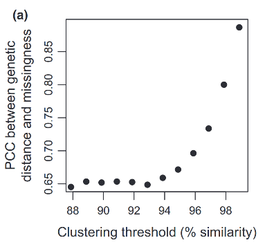

Hyla cinerea:

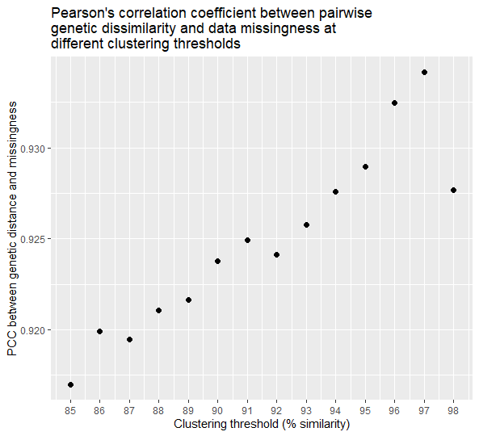

Based on their explanation and interpretations, it appears that 95 might be the optimal threshold for this metric of our data.

#### Potential Errors

Samples that have extremely low number of reads may break the R script. To fix this you will need to branch your step seven and remove those samples.

First load your ipyrad environment:

```bash
module load miniconda3
source activate ipyrad-env
```

Then, run the following command to branch a new run that excludes the necessary samples. The `-p` parameter should be the parameter file of the original run that you are branching off of. The `-b` parameter should be the new assembly name. Everything after the `-` should be a list of the samples to exclude. After you run the below code (make sure to modify the species abbreviations and samples), it will create a new parameter file named like `params-hyci_clustOpt85_step7_miss.txt`.

```bash
ipyrad -p params-hyci_clustOpt85.txt -b hyci_clustOpt85_step7_miss - FLMNH162452.trimmed B_MSB74657-B.trimmed
```

Here is a copy of code that includes ALL clustOpt85-97. Make sure to change the species abbreviation and the samples being removed. Each line below should be run SEPARATELY. Note: If you had to branch at step 7 earlier in the clustOpt steps, then instead of branching from “params-hyci_clustOpt85.txt”, you would be branching from “params-hyci_clustOpt85_step7.txt”.

```bash
ipyrad -p params-hyci_clustOpt85.txt -b hyci_clustOpt85_step7_miss - FLMNH162452.trimmed B_MSB74657-B.trimmed
ipyrad -p params-hyci_clustOpt86.txt -b hyci_clustOpt86_step7_miss - FLMNH162452.trimmed B_MSB74657-B.trimmed
ipyrad -p params-hyci_clustOpt87.txt -b hyci_clustOpt87_step7_miss - FLMNH162452.trimmed B_MSB74657-B.trimmed
ipyrad -p params-hyci_clustOpt88.txt -b hyci_clustOpt88_step7_miss - FLMNH162452.trimmed B_MSB74657-B.trimmed
ipyrad -p params-hyci_clustOpt89.txt -b hyci_clustOpt89_step7_miss - FLMNH162452.trimmed B_MSB74657-B.trimmed
ipyrad -p params-hyci_clustOpt90.txt -b hyci_clustOpt90_step7_miss - FLMNH162452.trimmed B_MSB74657-B.trimmed
ipyrad -p params-hyci_clustOpt91.txt -b hyci_clustOpt91_step7_miss - FLMNH162452.trimmed B_MSB74657-B.trimmed
ipyrad -p params-hyci_clustOpt92.txt -b hyci_clustOpt92_step7_miss - FLMNH162452.trimmed B_MSB74657-B.trimmed
ipyrad -p params-hyci_clustOpt93.txt -b hyci_clustOpt93_step7_miss - FLMNH162452.trimmed B_MSB74657-B.trimmed
ipyrad -p params-hyci_clustOpt94.txt -b hyci_clustOpt94_step7_miss - FLMNH162452.trimmed B_MSB74657-B.trimmed
ipyrad -p params-hyci_clustOpt95.txt -b hyci_clustOpt95_step7_miss - FLMNH162452.trimmed B_MSB74657-B.trimmed
ipyrad -p params-hyci_clustOpt96.txt -b hyci_clustOpt96_step7_miss - FLMNH162452.trimmed B_MSB74657-B.trimmed
ipyrad -p params-hyci_clustOpt97.txt -b hyci_clustOpt97_step7_miss - FLMNH162452.trimmed B_MSB74657-B.trimmed
```

Now that you have branched your assembly, make a copy of the slurm script associated with the original run. You can use a copy command to make a copy of the slurm script with a new name, like below. Note: Again, if you had to branch at step 7 earlier in the clustOpt steps, then instead of copying from “hyci_clustOpt85.slurm”, you would be copying from “hyci_clustOpt85_step7.slurm”.

```bash
cp hyci_clustOpt85.slurm hyci_clustOpt85_step7_miss.slurm
```

Then, open the new slurm script using `nano`. Change the parameter file to the new parameter file we created from branching. Also change the `-s` parameter to `7` (rather than `1234567`). Save and exit the slurm file, and then run it using `sbatch`.

### Slope of Genetic Divergence versus Geographic Distance

First, create a csv file that has columns `sample` , `lat` , and `long` using the following code. You will need to make sure you have a CSV version of the All_Samples_Sequenced

```r
library(readr)

# enter your species abbreviation !!!!
prefix <- "hyci"

# Set file paths
vcf_file <- paste0(prefix, "_clustOpt85.vcf") # this can be any clustOpt number you used, it does not matter
master_csv <- "ALL_Samples_Sequenced_20250821.csv"
output_csv <- paste0(prefix, "_clustOpt_IBD_latlong.csv")

# Extract samples from the vcf file
vcf_line11 <- readLines(vcf_file, n = 11)[11] # Read line 11 of the VCF file which contains sample names
vcf_fields <- strsplit(vcf_line11, "\t")[[1]] # Split the line by tabs
vcf_samples_trimmed <- vcf_fields[10:length(vcf_fields)] # Extract sample names (everything after the 9th column)
vcf_samples_clean <- sub("\\.trimmed$", "", vcf_samples_trimmed) # Remove ".trimmed" from sample names

# Read in excel sheet data
master_data <- read_csv(master_csv, col_select = c(UWBC_sampleName, decimalLatitude, decimalLongitude))

# Match VCF sample names (cleaned) to the master CSV, keeping VCF order
matched_data <- master_data[match(vcf_samples_clean, master_data$UWBC_sampleName), ]

# Add the VCF-ordered sample names as a new column to preserve order
matched_data$sample <- vcf_samples_trimmed  # overwrite just in case
colnames(matched_data) <- c("UWBC_sampleName", "lat", "long", "sample")

# Check for unmatched samples
if (any(is.na(matched_data$lat)) || any(is.na(matched_data$long))) {
  warning("Some samples from the VCF were not found in the master CSV!")
}

# Write the output CSV
write.csv(matched_data, output_csv, row.names = FALSE)
```

The code will give an error if some of the samples were not found when pulling from the All_Samples_sequenced spreadsheet. You may need to manually edit the CSV file if samples were not properly matched. Once everything finishes correctly, run the following script in R (modified from the original clustOpt script). Make sure to change the species abbreviation. Set your working directory to where your files are located.

```r
if (!requireNamespace("BiocManager", quietly=TRUE))
    install.packages("BiocManager")
BiocManager::install("SNPRelate")
```

```r
library(geosphere)
library(SNPRelate)

#empty variables that will be filled as the code runs
clusters <- c()
slopeList <- c()

### Make sure that there are exactly two flags–the VCF file input list [1] and the latlong file [2]
args = c(paste0(prefix, "_vcfListFile.txt"), paste0(prefix, "_clustOpt_IBD_latlong.csv"))
if (length(args)!=2) {
  stop("Exactly two arguments must be supplied (<vcf file> and <latLongFile>).n", call.=FALSE)
}

# Pull in the VCF filenames
vcfFiles <- scan(args[1], what = character(), quiet=T)

# Set up the geographic distance matrix:
latLongFile <- read.csv(args[2], sep=",", header=T) #changes the sep
geoDistMatrix <- matrix(nrow=length(latLongFile$sample), ncol=length(latLongFile$sample))
rownames(geoDistMatrix) <- latLongFile$sample
colnames(geoDistMatrix) <- latLongFile$sample

# Calculate the pairwise geographic distance between each pair of points, in km:
for (i in 1:length(latLongFile$sample)) {
    for (j in 1:length(latLongFile$sample)) {
        geoDistMatrix[i,j] <- distm(c(latLongFile$long[i], latLongFile$lat[i]), c(latLongFile$long[j], latLongFile$lat[j]), fun = distHaversine) / 1000
    }
}

for (i in 1:length(vcfFiles)) {
    gdsOut <- paste(gsub(".vcf","", vcfFiles[i], fixed=T), '.pcaVar.gds', sep="")
    snpgdsVCF2GDS(vcfFiles[i], gdsOut, verbose=F)
    genofile <- snpgdsOpen(gdsOut)
    ibsMat <- snpgdsIBS(genofile, num.thread=2, verbose=F, autosome.only=FALSE) #added the autosome.only)

#    cat(head(rownames(geoDistMatrix)))
#    cat(head(ibsMat$sample.id))
#    cat(match(rownames(geoDistMatrix), ibsMat$sample.id), "\n")

    # Rearrange IBS matrix to the same order as geoDistMatrix
    ibsMatRearranged <- ibsMat$ibs[match(rownames(geoDistMatrix), ibsMat$sample.id), match(rownames(geoDistMatrix), ibsMat$sample.id)]

    slopeToReport <- lm(100-ibsMatRearranged[lower.tri(ibsMatRearranged, diag=F)] ~ geoDistMatrix[lower.tri(geoDistMatrix, diag=F)])$coefficients[2]
    cat("IBD slope for ", vcfFiles[i], ": ", 100 * 100 * slopeToReport, "% increased SNP divergence per 100km\n", sep="")

    # --- NEW: extract cluster number from filename ---
    # Example filename: "hyci_clustOpt85.vcf"
    cluster_num <- as.integer(sub(".*clustOpt(\\d+)\\.vcf", "\\1", vcfFiles[i]))

    # Store the values
    clusters <- c(clusters, cluster_num)
    slopeList <- c(slopeList, (100 * 100 * slopeToReport))

    # -----------------------

    snpgdsClose(genofile)
    file.remove(gdsOut)
}


# After finishing all files, write CSV
results_df <- data.frame(clust = clusters, pct_SNP_divergence_per_100km = slopeList)
write.csv(results_df, paste0(prefix, "_clustOpt_IBD.csv"), row.names = FALSE)
```

The code will print out the IBD slope for each clustOpt threshold:

> IBD slope for hyci_clustOpt85.vcf: 0.7160066% increased SNP divergence per 100km

> IBD slope for hyci_clustOpt86.vcf: 0.7103856% increased SNP divergence per 100km

> IBD slope for hyci_clustOpt87.vcf: 0.7048849% increased SNP divergence per 100km

> IBD slope for hyci_clustOpt88.vcf: 0.6991359% increased SNP divergence per 100km

> IBD slope for hyci_clustOpt89.vcf: 0.690336% increased SNP divergence per 100km

> IBD slope for hyci_clustOpt90.vcf: 0.6866169% increased SNP divergence per 100km

> IBD slope for hyci_clustOpt91.vcf: 0.6782644% increased SNP divergence per 100km

> IBD slope for hyci_clustOpt92.vcf: 0.6674422% increased SNP divergence per 100km

> IBD slope for hyci_clustOpt93.vcf: 0.6613385% increased SNP divergence per 100km

> IBD slope for hyci_clustOpt94.vcf: 0.6412194% increased SNP divergence per 100km

> IBD slope for hyci_clustOpt95.vcf: 0.6306108% increased SNP divergence per 100km

> IBD slope for hyci_clustOpt96.vcf: 0.6023792% increased SNP divergence per 100km

> IBD slope for hyci_clustOpt97.vcf: 0.5733166% increased SNP divergence per 100km

> IBD slope for hyci_clustOpt98.vcf: 0.5340749% increased SNP divergence per 100km

These will be output into a CSV file automatically.

You can now print a graph.

```r
library(ggplot2)

IBD_csv <- read.csv(paste0(prefix, "_clustOpt_IBD.csv"))
IBD_plot <- ggplot(IBD_csv, aes(x = clust, y = pct_SNP_divergence_per_100km)) + geom_point(size=2) + labs(title="Slopes of genetic isolation by geographic \ndistance across samples", x = "Clustering threshold (% similarity)", y = "% increased SNP divergence per 100 km")  + scale_x_continuous(labels = as.character(IBD_csv$clust), breaks = IBD_csv$clust)
IBD_plot

ggsave(IBD_plot, filename=paste0(prefix, "_IBD.png"), bg="transparent", height=6, width=6, units="in")
```

The paper says:

> “We expect that oversplitting will lead to a reduction in the positive slope of genetic divergence as a function of geographic distance at the clustering threshold that begins to split the most divergent homologue alleles.”

In their dataset, they determined that 95% was the optimal clustering threshold based on this metric. It seems that they selected the threshold that happens just before a large decrease on the y-axis.

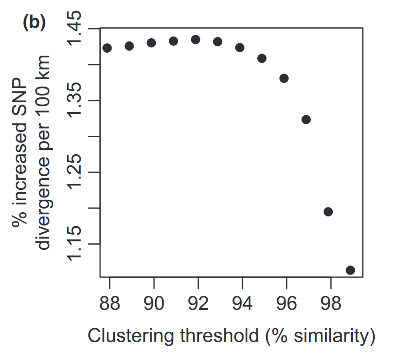

Hyla cinerea:

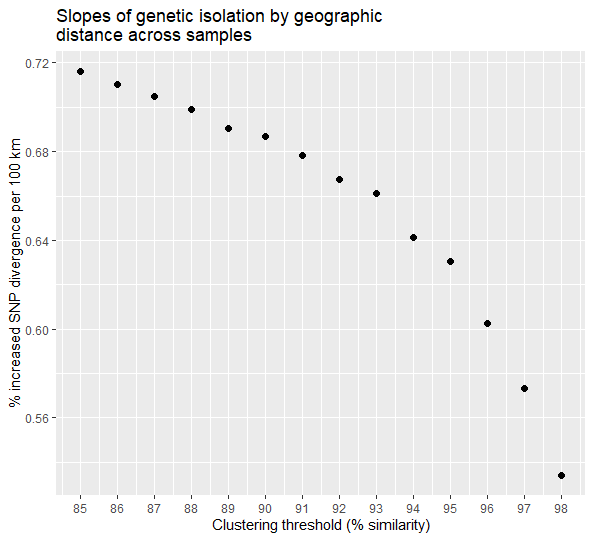

Based on their explanation and interpretations, it appears that 93 or 95 would be the optimal thresholds for this metric of our data.

### Total Number of SNPs

The following code will extract the number of SNPs from each of your `clustOpt##_stats.txt` files that you downloaded. As an example, if the second to last line in the file says `snps matrix size: (51, 312453), 65.92% missing sites.`, then `312453` would be the number of SNPs.

```r
# enter your species abbreviation !!!!
prefix <- "hyci"

# Define the range of cluster thresholds you have files for
clust_values <- 85:97

# Initialize a vector to store SNP counts
snp_counts <- numeric(length(clust_values))

# Loop through each threshold, read the corresponding stats file, and extract the SNP count
for (i in seq_along(clust_values)) {
  clust <- clust_values[i]

  # Construct the filename (change prefix if needed)
  filename <- paste0(prefix, "_clustOpt", clust, "_stats.txt")

  # Read all lines from the stats file
  lines <- readLines(filename)

  # Find the line containing "snps matrix size"
  snp_line <- lines[grepl("snps matrix size", lines)]

  # Extract the SNP count using a regex pattern
  # Example line: snps matrix size: (51, 312453), 65.92% missing sites.
  snp_count <- as.numeric(sub(".*\\(\\d+,\\s*(\\d+)\\).*", "\\1", snp_line))

  # Store the SNP count
  snp_counts[i] <- snp_count
}

# Create the dataframe
clustOpt_df <- data.frame(
  clust = clust_values,
  SNPs = snp_counts
)

# Write to CSV
write.csv(clustOpt_df, file = paste0(prefix, "_clustOpt_SNPs.csv"), row.names = FALSE)
```

Now plot the SNPs as a graph.

```r
library(scales)
library(ggplot2)

SNPs_csv <- read.csv(paste0(prefix, "_clustOpt_SNPs.csv"))
SNPs_plot <- ggplot(SNPs_csv, aes(x = clust, y = SNPs)) + geom_point(size=2) + labs(title="Total SNPs recovered across different clustering \nthresholds", x = "Clustering threshold (% similarity)", y = "Total SNPs")  + scale_x_continuous(labels = as.character(SNPs_csv$clust), breaks = SNPs_csv$clust) + scale_y_continuous(labels = label_comma())
SNPs_plot

ggsave(SNPs_plot, filename=paste0(prefix, "_SNPs.png"), bg="transparent", height=6, width=6, units="in")
```

This will print out a dot chart showing the total SNPs per clustering threshold.

The paper says:

> “We expect that for both heterozygosity and the total number of SNPs the optimal clustering threshold should be at or near the value that returns the maximum value for each.”

In their dataset, they determined that 95% was the optimal clustering threshold based on this metric.

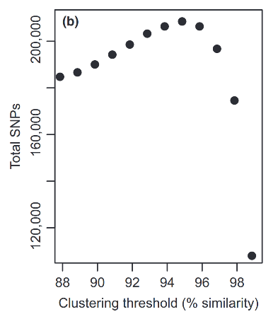

Hyla cinerea:

[figure not shown]

Based on their explanation and interpretations, it appears that 94 would be the optimal threshold for this metric of our data.

### Fraction of Variance Explained by the Main Principal Components of Genetic Variation

Use the following code to run the PCAs (modified from the original clustOpt script). Make sure to change the species abbreviation. The code will put the variance explained by the first 8 PCs for each clustOpt threshold into a csv file.

```r
# Load SNPRelate
library(SNPRelate)

# enter your species abbreviation !!!!
prefix <- "hyci"

# Create empty variables
clusters <- c()
varList <- c()

### Make sure that there is exactly one flag–the VCF file input list
args = c(paste0(prefix, "_vcfListFile.txt"),"8") #  8 is the number of PCs
if (length(args)!=2) {
  stop("Exactly two arguments must be supplied (<vcf file list> and <numPCsToSum>).n", call.=FALSE)
}

### Put the VCF filenames into a vector
vcfFiles <- scan(args[1], what = character(), quiet=T)

for (i in 1:length(vcfFiles)) {
    gdsOut <- paste(gsub(".vcf","", vcfFiles[i], fixed=T), '.pcaVar.gds', sep="") # makes gds file name
    snpgdsVCF2GDS(vcfFiles[i], gdsOut, verbose=F) #makes the gds file
    genofile <- snpgdsOpen(gdsOut) # opens gds file
    pcaz <- snpgdsPCA(genofile, num.thread=2, verbose=F, autosome.only=FALSE) #added the autosome.only
    varExplained <- sum(pcaz$varprop[1:args[2]])
    cat("Variance explained by first ", args[2], " PCs for ", vcfFiles[i], ": ", varExplained, "\n", sep="")

    # --- NEW: extract cluster number from filename ---
    # Example filename: "hyci_clustOpt85.vcf"
    cluster_num <- as.integer(sub(".*clustOpt(\\d+)\\.vcf", "\\1", vcfFiles[i]))

    # Store the values
    clusters <- c(clusters, cluster_num)
    varList <- c(varList, varExplained)

    # ------------
    snpgdsClose(genofile)
    file.remove(gdsOut)
}

# After finishing all files, write CSV
results_df <- data.frame(clust = clusters, variance = varList)
write.csv(results_df, paste0(prefix, "_clustOpt_PCA.csv"), row.names = FALSE)
```

Now you can print a figure.

```r
library(ggplot2)

PCA_csv <- read.csv(paste0(prefix, "_clustOpt_PCA.csv"))
PCA_plot <- ggplot(PCA_csv, aes(x = clust, y = variance)) + geom_point(size=2) + labs(title="Cumulative variance of all biallelic SNPs recovered \n by ipyrad explained by the first 8 principal \ncomponents across different clustering thresholds.", x = "Clustering threshold (% similarity)", y = "Cumulative variance in first n PCs") + scale_x_continuous(labels = as.character(PCA_csv$clust), breaks = PCA_csv$clust)
PCA_plot

ggsave(PCA_plot, filename=paste0(prefix, "_PCA.png"), bg="transparent", height=6, width=6, units="in")
```

The paper says:

> “We expect the fraction of variance explained by the first eight principal components to increase with clustering threshold (as the amount of data generally increases with clustering threshold) until a certain threshold when bias from oversplitting more strongly influences the results, after which the proportion of variance explained by those principal components should decrease.”

In their dataset, they determined that 96% was the optimal clustering threshold based on this metric.

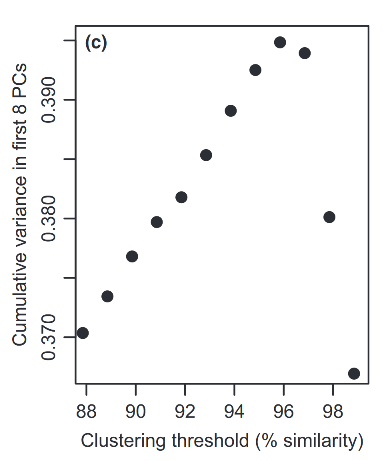

Hyla cinerea:

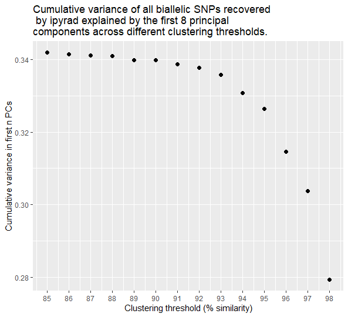

There is no “peak” that then decreases like we see in the paper’s dataset. I am interpreting this similar to the IBD slopes where I am selecting the threshold that happens just before a large decrease on the y-axis. Based on this, it appears that 93 or 95 would be the optimal threshold for this metric of our data.

### Heterozygosity

The following code will extract heterozygosity values from your clustOpt##_s5_consensus.txt files and create a new csv files with the sample names, heterozygosity values, and clustering thresholds.

```r
library(dplyr)

# enter your species abbreviation !!!!
prefix <- "hyci"

# Directory containing your files (change if needed)
file_dir <- "."  # current working directory

# List all files matching the pattern
files <- list.files(path = file_dir, pattern = paste0("^", prefix, "_clustOpt\\d+_s5_consensus\\.txt$"), full.names = TRUE)

# Initialize an empty data frame to store results
combined_data <- data.frame()

for (file in files) {
  # Extract clustering threshold from filename
  clust_val <- as.integer(sub(".*clustOpt(\\d+)_s5_consensus\\.txt", "\\1", basename(file)))

  # Read the file with whitespace separator, allow multiple spaces/tabs between columns
  df <- read.table(file, header = TRUE, strip.white = TRUE, row.names = NULL)

  # Extract sample name (1st col) and heterozygosity (last col)
  sample_col <- df[[1]]
  het_col <- df[[ncol(df)]]

  # Create new data frame with desired columns + clust
  temp_df <- data.frame(sample = sample_col,
                        heterozygosity = het_col,
                        clust = clust_val)

  # Append to combined data
  combined_data <- bind_rows(combined_data, temp_df)
}

# Write combined data to CSV
write.csv(combined_data, paste0(prefix, "_clustOpt_het.csv"), row.names = FALSE)
```

Now create a plot in R.

```r
library(ggplot2)

het_csv <- read.csv(paste0(prefix, "_clustOpt_het.csv"))
het_plot <- ggplot(het_csv, aes(x = clust, y = heterozygosity, group = clust)) + geom_boxplot() + scale_x_continuous(labels = as.character(het_csv$clust), breaks = het_csv$clust) + labs(title="Heterozygosity", x = "Clustering threshold (% similarity)", y = "Heterozygosity")
het_plot

ggsave(het_plot, filename=paste0(prefix, "_het.png"), bg="transparent", height=6, width=6, units="in")
```

The paper says:

> “We expect that for both heterozygosity and the total number of SNPs the optimal clustering threshold should be at or near the value that returns the maximum value for each.”

In their dataset, they determined that 96% was the optimal clustering threshold based on this metric.

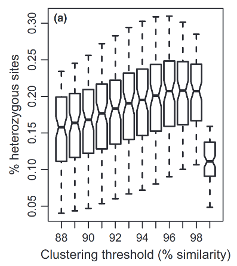

Hyla cinerea:

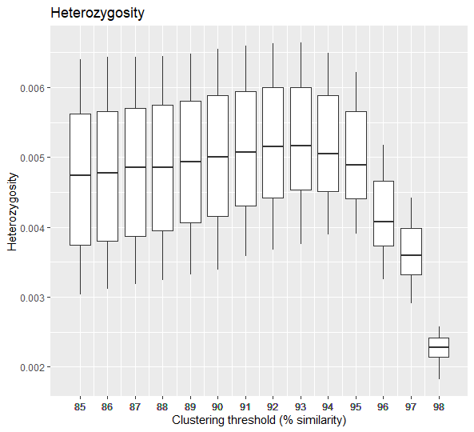

Based on their explanation and interpretations, it appears that 93 would be the optimal threshold for this metric of our data.

## Upload your csv files, plots, and R script

You need to upload your six csv files, five plots, and the R script into a shared folder for people to access in the future. Go into the shared clustOpt folder and create a new folder for your species (such as `Hyla_cinerea`). Upload your 12 files.

[figure not shown]

# Branching to create 2-4 different datasets

## Brief introduction

We want to create 4 (possibly 2) different datasets for each species. This will be different combinations of cluster and MSL thresholds.

When we ran the cluster optimization assemblies, we had the `min_samples_locus` (MSL) ipyrad parameter (parameter #21) set to the default of 4. This means that a locus was only included in the final assembly if at least 4 of the samples had that locus. Using a number this low means there will be a lot of missing data in the samples, especially as the total number of samples in the assembly increases.

We want to try two different thresholds for MSL. We want one set of assemblies to include loci occurring in at least 50% of sampled individuals, and the other set will be stricter at 80%. The MSL parameter however does not use percentages and rather uses strict number of individuals, so we will need to calculate how many samples are needed to meet those percentages.

Additionally, two datasets will correspond to the optimal clustering threshold for each species that was determined after the clustOpt analyses. The two other datasets will correspond to a shared clustering threshold that will be the same across all species.

This results in four datasets for each species:

1. Shared clustering threshold with 50% MSL
2. Shared clustering threshold with 80% MSL
3. Optimal clustering threshold with 50% MSL
4. Optimal clustering threshold with 80% MSL

In some instances a species may only have two datasets if the optimal clustering threshold and shared clustering threshold are the same.

We need to create 4 (or 2) new assemblies for each of our species by branching at step 7 and then running step 7 in ipyrad.

## Identify your datasets

Before branching your assemblies, first identify the two clustering thresholds you are working with.

**The shared clustering threshold is 93.**

To find the optimal clustering threshold, find your species in the project spreadsheet. **The clustOpt## column contains your optimal clustering threshold.**

For the number of samples corresponding to 50% and 80% `min_samples_locus`, use the numbers in the corresponding columns in the same spreadsheet: `N_min50` and `N_min80`.

## Branching the assemblies

Now we can branch our assemblies. Log into CARC. Load your ipyrad environment.

```bash
module load miniconda3
source activate ipyrad-env
```

Navigate to the location of your species clustOpt directory. Make sure to change the species name:

```bash
cd /carc/scratch/projects/lnbarrow2016221/ipyradAssemblies/Hyla_cinerea/clustOpt/
```

### Shared clustering threshold

We will first make two branches for the shared clustering threshold, corresponding to the MSL 50% and 80%. Make sure to change the species abbreviation.

```bash
ipyrad -p params-hyci_clustOpt93.txt -b hyci_clustOpt93_MSL50
```

```bash
ipyrad -p params-hyci_clustOpt93.txt -b hyci_clustOpt93_MSL80
```

### Optimal clustering threshold

Now make two branches for the optimal clustering threshold for your species. Makes sure to change the species abbreviation and the clustering threshold for both. **You do NOT need to do this if the optimal clustering threshold is the same as the shared clustering threshold.**

```bash
ipyrad -p params-hyci_clustOpt##.txt -b hyci_clustOpt##_MSL50
```

```bash
ipyrad -p params-hyci_clustOpt##.txt -b hyci_clustOpt##_MSL80
```

## Editing the branched parameter files

We need to edit the branched parameter files to change the `min_samples_locus` parameter.

Open each of the following parameter files. Arrow down to parameter 21 min_samples_locus and change the 4 to the value that corresponds with MSL50 or MSL80. **MAKE SURE YOU ARE USING THE CORRECT VALUE FOR THE CORRECT ASSEMBLY.** For example, if the assembly is MSL80 then this value should be 80% of the total number of samples that was calculated earlier.

Save each parameter file using `CTRL + O` and then press `ENTER`. Use `CTRL + X` to exit. The codes below are to open the four different parameter files. Make sure to change the species abbreviations and the clustering threshold when necessary. Again, if you have a species where the shared and optimal clustering thresholds are the same, you only need to do one set of these, not both.

Shared clustering threshold:

```bash
nano params-hyci_clustOpt93_MSL50.txt
```

```bash
nano params-hyci_clustOpt93_MSL80.txt
```

Optimal clustering threshold:

```bash
nano params-hyci_clustOpt##_MSL50.txt
```

```bash
nano params-hyci_clustOpt##_MSL80.txt
```

## Create and run slurm scripts

We need to create a slurm script for each of the 4 assemblies (or 2). Use the codes below to create and name the files, and paste in the contents. Save each slurm script using `CTRL + O` and then press `ENTER`. Use `CTRL + X` to exit.

### Shared clustering threshold:

Remember to change the species abbreviation in the file names. Within the slurm script, change the species abbreviations and your email.

#### MSL50

```bash
nano hyci_clustOpt93_MSL50.slurm
```

```bash
#!/bin/bash

#SBATCH --ntasks=1
#SBATCH --cpus-per-task=8
#SBATCH --time=1:00:00
#SBATCH --job-name=c93MSL50
#SBATCH --output=_clustOpt93MSL50_out_%j
#SBATCH --error=_clustOpt93MSL50_error_%j
#SBATCH --partition=general
#SBATCH --account=2016221
#SBATCH --mail-type=ALL
#SBATCH --mail-user=youremail@unm.edu

## activate conda environment
module load miniconda3
source activate ipyrad-env

## call ipyrad on your params file, running step one (demultiplex)
ipyrad -p params-hyci_clustOpt93_MSL50.txt -s 7 -c ${SLURM_CPUS_PER_TASK}
```

```bash
sbatch hyci_clustOpt93_MSL50.slurm
```

#### MSL80

```bash
nano hyci_clustOpt93_MSL80.slurm
```

```bash
#!/bin/bash

#SBATCH --ntasks=1
#SBATCH --cpus-per-task=8
#SBATCH --time=1:00:00
#SBATCH --job-name=c93MSL80
#SBATCH --output=_clustOpt93MSL80_out_%j
#SBATCH --error=_clustOpt93MSL80_error_%j
#SBATCH --partition=general
#SBATCH --account=2016221
#SBATCH --mail-type=ALL
#SBATCH --mail-user=youremail@unm.edu

## activate conda environment
module load miniconda3
source activate ipyrad-env

## call ipyrad on your params file, running step one (demultiplex)
ipyrad -p params-hyci_clustOpt93_MSL80.txt -s 7 -c ${SLURM_CPUS_PER_TASK}
```

```bash
sbatch hyci_clustOpt93_MSL80.slurm
```

### Optimal clustering threshold:

Remember to change the species abbreviation and clustering threshold in the file names. Within the slurm script, change the species abbreviation, your email, and the clustering threshold for the `-p` parameter, job name, and output and error files.

#### MSL50

```bash
nano hyci_clustOpt##_MSL50.slurm
```

```bash
#!/bin/bash

#SBATCH --ntasks=1
#SBATCH --cpus-per-task=8
#SBATCH --time=1:00:00
#SBATCH --job-name=c##MSL50
#SBATCH --output=_clustOpt##MSL50_out_%j
#SBATCH --error=_clustOpt##MSL50_error_%j
#SBATCH --partition=general
#SBATCH --account=2016221
#SBATCH --mail-type=ALL
#SBATCH --mail-user=youremail@unm.edu

## activate conda environment
module load miniconda3
source activate ipyrad-env

## call ipyrad on your params file, running step one (demultiplex)
ipyrad -p params-hyci_clustOpt##_MSL50.txt -s 7 -c ${SLURM_CPUS_PER_TASK}
```

```bash
sbatch hyci_clustOpt##_MSL50.slurm
```

#### MSL80

```bash
nano hyci_clustOpt##_MSL80.slurm
```

```bash
#!/bin/bash

#SBATCH --ntasks=1
#SBATCH --cpus-per-task=8
#SBATCH --time=1:00:00
#SBATCH --job-name=c##MSL80
#SBATCH --output=_clustOpt##MSL80_out_%j
#SBATCH --error=_clustOpt##MSL80_error_%j
#SBATCH --partition=general
#SBATCH --account=2016221
#SBATCH --mail-type=ALL
#SBATCH --mail-user=youremail@unm.edu

## activate conda environment
module load miniconda3
source activate ipyrad-env

## call ipyrad on your params file, running step one (demultiplex)
ipyrad -p params-hyci_clustOpt##_MSL80.txt -s 7 -c ${SLURM_CPUS_PER_TASK}
```

```bash
sbatch hyci_clustOpt##_MSL80.slurm
```

## After running

Step 7 of the assemblies should not take very long to run. They usually finish in under an hour for most data sets. When finished, first grant permissions for the files in your clustOpt folder. Make sure to change the species name.

```bash
chmod -R g+w /carc/scratch/projects/lnbarrow2016221/ipyradAssemblies/Hyla_cinerea/clustOpt
```

We want to record the total number of loci from each assembly. Record the total number of loci in each of the four assemblies for your species in the appropriate columns in the project spreadsheet.

The names of the associated columns are below:

Shared clustering threshold with 50% MSL: `clustSame_min50_nloci`

Shared clustering threshold with 80% MSL: `clustSame_min80_nloci`

Optimal clustering threshold with 50% MSL: `clustOpt_min50_nloci`

Optimal clustering threshold with 80% MSL: `clustOpt_min80_nloci`

**NOTE: The MSL80 assemblies should have FEWER loci than the MSL50 assemblies if they have the same clustOpt threshold. If this is not the case, then something is wrong.**

You can use the `less` command to open a read only version of the assembly stats file.

Within the first part of the stats file, locate the number that intersects the `retained_loci` column and `total_filtered_loci` row. This number is the total number of loci kept in the assembly.

You will need to press the `Q` key to exit from the `less` screen.

You will need to change the species name and species abbreviations for each code below.

### Shared clustering threshold

#### MSL50

```bash
less /carc/scratch/projects/lnbarrow2016221/ipyradAssemblies/Hyla_cinerea/clustOpt/hyci_clustOpt93_MSL50_outfiles/hyci_clustOpt93_MSL50_stats.txt
```

#### MSL80

```bash
less /carc/scratch/projects/lnbarrow2016221/ipyradAssemblies/Hyla_cinerea/clustOpt/hyci_clustOpt93_MSL80_outfiles/hyci_clustOpt93_MSL80_stats.txt
```

### Optimal clustering threshold

Along with the species name and species abbreviation, also make sure to change the numbers for the clustering threshold.

#### MSL50

```bash
less /carc/scratch/projects/lnbarrow2016221/ipyradAssemblies/Hyla_cinerea/clustOpt/hyci_clustOpt##_MSL50_outfiles/hyci_clustOpt##_MSL50_stats.txt
```

#### MSL80

```bash
less /carc/scratch/projects/lnbarrow2016221/ipyradAssemblies/Hyla_cinerea/clustOpt/hyci_clustOpt##_MSL80_outfiles/hyci_clustOpt##_MSL80_stats.txt
```